# Proyecto Ciencia de Datos

MA1042: Matemáticas y ciencia de datos para la toma de decisiones

Azul Fernanda Paniagua Bucio

# Fase 2

## Lectura de datos

```r
setwd("C:/Users/azulp/Downloads")

library(readxl)
datos<- read_excel("./A01424351_Bitacora.xlsx",sheet = "Información")
attach(datos)
```

## Limpieza de datos

```r
library(janitor)
datos<-clean_names(datos)

head(datos)
```

| fecha | semana | producto | calorias_kcal | carbohidratos_gramos | colesterol_miligramos | grasas_totales_gramos | grasas_saturadas_gramos | grasas_trans_gramos | proteina_gramos | sodio_miligramos | azucares_gramos | fibra_gramos | potasio_miligramos | calcio_miligramos | hierro_miligramos | vitamina_a_mg | vitamina_c_mg | vitamina_d_mg | porciones_por_envase | tamano_de_la_porcion_gramos |
| --- | --- | --- | --- | --- | --- | --- | --- | --- | --- | --- | --- | --- | --- | --- | --- | --- | --- | --- | --- | --- |
| 45152.0 | 2 | huevo_con_chorizo | 167.00 | 5.33 | 450.0 | 11.41 | 3.81 | 0.00 | 10.66 | 390.00 | 1.76 | 1.00 | 143.0 | NA | 0.00 | 0.980 | 0.00 | 0.0018 | 1 | 250 |
| 45153.0 | 2 | fruta | 43.00 | 10.50 | 0.0 | 0.20 | 0.00 | 0.00 | 0.90 | 12.00 | 9.10 | 1.80 | 208.8 | 4.98 | 0.72 | 34.473 | 10.27 | 0.0000 | 1 | 112 |
| 45152.0 | 2 | licuado_de_proteina | 159.88 | 3.00 | 0.0 | 5.80 | 0.50 | 0.00 | 23.92 | 480.00 | 0.33 | 3.92 | 0.0 | 105.00 | 17.40 | 36.960 | 0.00 | 0.0020 | 1 | 480 |
| 45152.0 | 2 | manzana | 40.00 | 10.50 | 0.0 | 0.00 | 0.00 | 0.00 | 0.00 | 1.00 | 8.00 | 2.50 | 70.0 | 0.08 | 0.10 | 0.012 | 3.22 | 0.0000 | 1 | 70 |
| 45152.0 | 2 | uvas | 67.00 | 17.00 | 0.0 | 0.20 | 0.00 | 0.00 | 0.00 | 2.00 | 16.00 | 0.90 | 0.0 | 0.00 | 0.00 | 0.000 | 0.00 | 0.0000 | 1 | 100 |
| 45152.0 | 2 | ensalada | 619.00 | 81.00 | 106.5 | 17.10 | 5.40 | 0.05 | 35.80 | 930.25 | 24.90 | 7.30 | 589.6 | 815.70 | 34.40 | 46.000 | 52.75 | NA | 1 | 400 |

## Revisión rápida

```r
library(naniar)
skimr::skim(datos)
```

Data summary

| Name | datos |
| --- | --- |
| Number of rows | 301 |
| Number of columns | 21 |
| _______________________ |  |
| Column type frequency: |  |
| character | 2 |
| numeric | 19 |
| ________________________ |  |
| Group variables | None |

**Variable type: character**

| skim_variable | n_missing | complete_rate | min | max | empty | n_unique | whitespace |
| --- | --- | --- | --- | --- | --- | --- | --- |
| fecha | 0 | 1.00 | 7 | 9 | 0 | 67 | 0 |
| producto | 41 | 0.86 | 4 | 24 | 0 | 37 | 0 |

**Variable type: numeric**

| skim_variable | n_missing | complete_rate | mean | sd | p0 | p25 | p50 | p75 | p100 | hist |
| --- | --- | --- | --- | --- | --- | --- | --- | --- | --- | --- |
| semana | 0 | 1.00 | 5.57 | 2.54 | 2.0 | 3.00 | 5.00 | 8.00 | 10.00 | ▇▇▃▆▅ |
| calorias_kcal | 42 | 0.86 | 226.42 | 207.31 | 40.0 | 45.00 | 159.88 | 237.00 | 1074.00 | ▇▁▂▁▁ |
| carbohidratos_gramos | 45 | 0.85 | 26.20 | 28.37 | 2.0 | 10.50 | 12.00 | 30.40 | 140.00 | ▇▁▂▁▁ |
| colesterol_miligramos | 48 | 0.84 | 88.00 | 147.63 | 0.0 | 0.00 | 0.00 | 106.50 | 450.00 | ▇▂▁▁▂ |
| grasas_totales_gramos | 42 | 0.86 | 8.64 | 9.02 | 0.0 | 0.20 | 6.70 | 15.20 | 54.50 | ▇▅▁▁▁ |
| grasas_saturadas_gramos | 49 | 0.84 | 2.44 | 2.78 | 0.0 | 0.00 | 0.50 | 5.40 | 18.00 | ▇▆▁▁▁ |
| grasas_trans_gramos | 55 | 0.82 | 0.02 | 0.16 | 0.0 | 0.00 | 0.00 | 0.00 | 2.00 | ▇▁▁▁▁ |
| proteina_gramos | 42 | 0.86 | 13.15 | 13.13 | 0.0 | 0.95 | 10.66 | 23.92 | 35.80 | ▇▂▁▂▃ |
| sodio_miligramos | 47 | 0.84 | 315.93 | 341.93 | 0.0 | 12.00 | 187.00 | 500.00 | 930.25 | ▇▁▃▁▃ |
| azucares_gramos | 49 | 0.84 | 9.19 | 8.73 | 0.0 | 1.40 | 9.10 | 14.05 | 31.40 | ▇▅▂▃▁ |
| fibra_gramos | 48 | 0.84 | 2.82 | 3.48 | 0.0 | 1.00 | 1.80 | 3.92 | 42.00 | ▇▁▁▁▁ |
| potasio_miligramos | 63 | 0.79 | 190.79 | 209.43 | 0.0 | 0.00 | 143.00 | 208.80 | 589.60 | ▇▇▁▁▃ |
| calcio_miligramos | 74 | 0.75 | 197.49 | 311.72 | 0.0 | 4.98 | 70.00 | 105.00 | 815.70 | ▇▁▁▁▂ |
| hierro_miligramos | 74 | 0.75 | 9.99 | 14.63 | 0.0 | 0.00 | 0.72 | 17.40 | 64.00 | ▇▂▂▁▁ |
| vitamina_a_mg | 76 | 0.75 | 23.11 | 19.22 | 0.0 | 0.01 | 34.47 | 36.96 | 46.00 | ▇▁▁▅▇ |
| vitamina_c_mg | 76 | 0.75 | 13.75 | 20.30 | 0.0 | 0.00 | 3.22 | 10.27 | 52.75 | ▇▁▁▁▂ |
| vitamina_d_mg | 115 | 0.62 | 0.00 | 0.00 | 0.0 | 0.00 | 0.00 | 0.00 | 0.00 | ▇▁▁▁▂ |
| porciones_por_envase | 43 | 0.86 | 1.28 | 1.75 | 0.2 | 1.00 | 1.00 | 1.00 | 20.00 | ▇▁▁▁▁ |
| tamano_de_la_porcion_gramos | 43 | 0.86 | 224.58 | 142.32 | 20.0 | 112.00 | 178.00 | 400.00 | 480.00 | ▇▆▁▁▆ |

```r
pct_miss(datos)
```

```
## [1] 16.95934
```

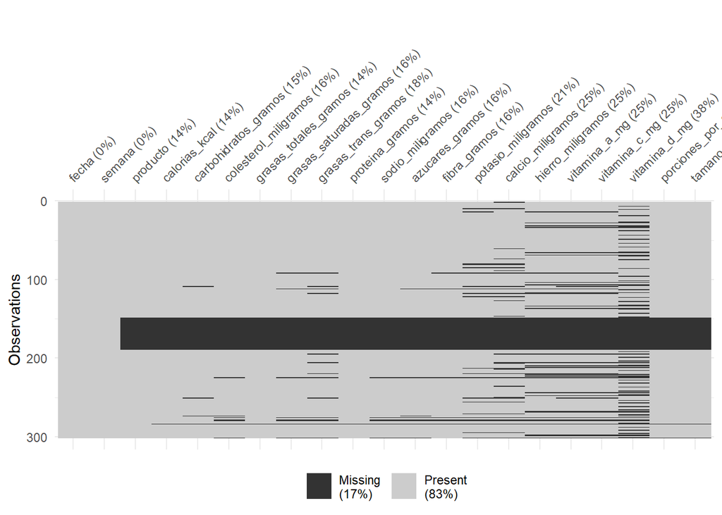

```r
vis_miss(datos)
```

## Imputación

En esta parte hacemos imputación y checamos normalidad

### Columna de producto

```r
library(fdth)
moda_producto <- mfv(datos$producto)
datos$producto[is.na(datos$producto)] <- moda_producto
moda_producto
```

```
## [1] "fruta"
```

### Columna de calorías

No hay normalidad

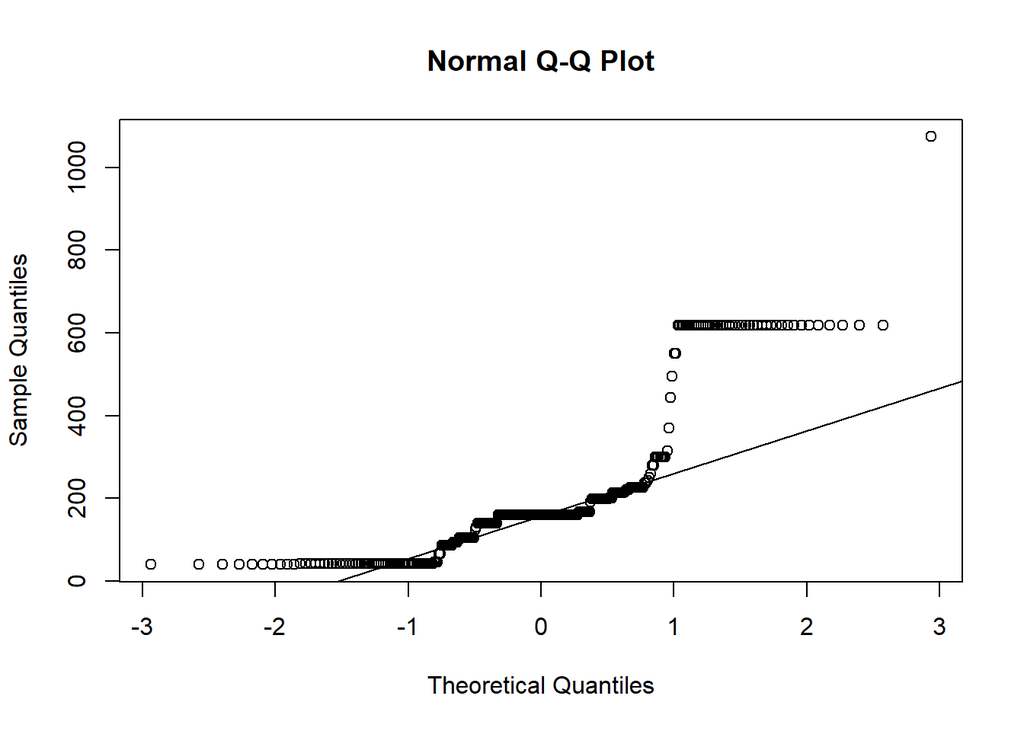

```r
mediana_cal <- median(datos$calorias_kcal, na.rm = TRUE)
datos$calorias_kcal[is.na(datos$calorias_kcal)] <- mediana_cal

qqnorm(datos$calorias_kcal)

qqline(datos$calorias_kcal)
```

### Columna de carbohidratos

No hay normalidad

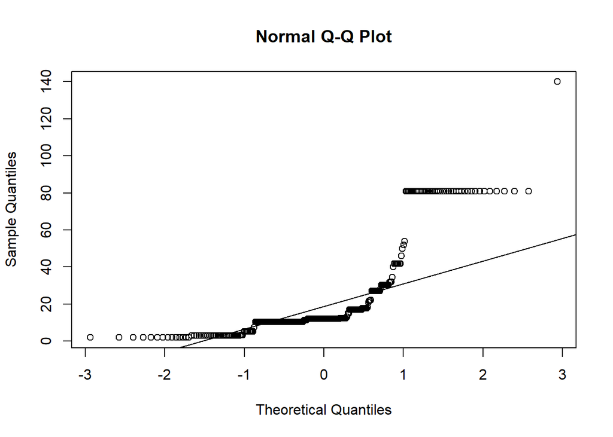

```r
mediana_carb <- median(datos$carbohidratos_gramos, na.rm = TRUE)
datos$carbohidratos_gramos[is.na(datos$carbohidratos_gramos)] <- mediana_carb

qqnorm(datos$carbohidratos_gramos)

qqline(datos$carbohidratos_gramos)
```

### Columna de colesterol

No hay normalidad

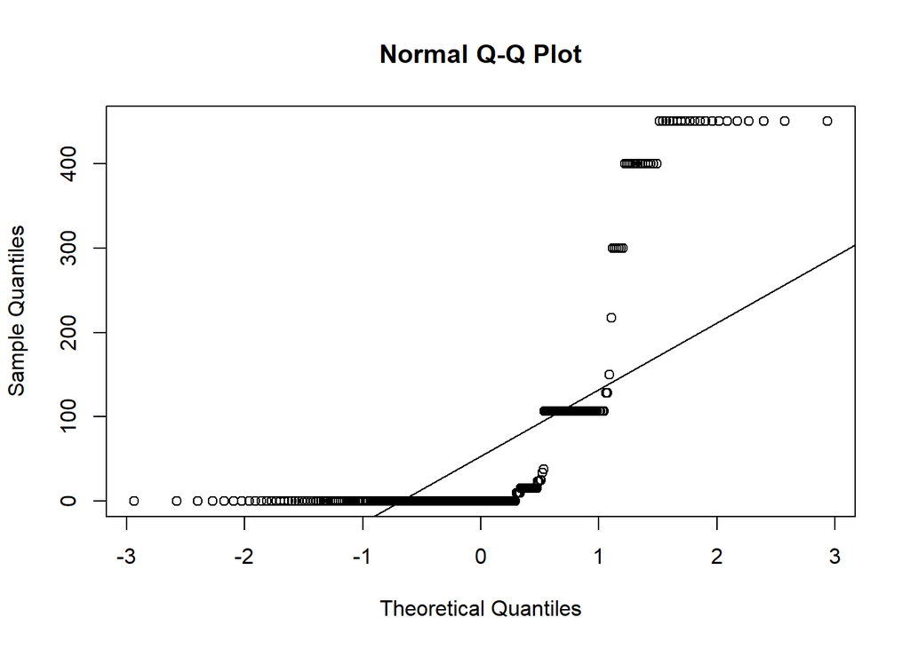

```r
mediana_col <- median(datos$colesterol_miligramos, na.rm = TRUE)
datos$colesterol_miligramos[is.na(datos$colesterol_miligramos)] <- mediana_col

qqnorm(datos$colesterol_miligramos)

qqline(datos$colesterol_miligramos)
```

### Columna de grasas totales

No hay normalidad

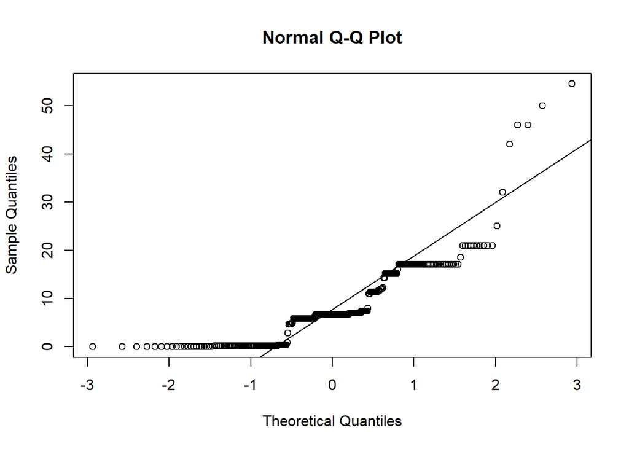

```r
mediana_grasas_tot <- median(datos$grasas_totales_gramos, na.rm = TRUE)
datos$grasas_totales_gramos[is.na(datos$grasas_totales_gramos)] <- mediana_grasas_tot

qqnorm(datos$grasas_totales_gramos)

qqline(datos$grasas_totales_gramos)
```

### Columna de grasas saturadas

No hay normalidad

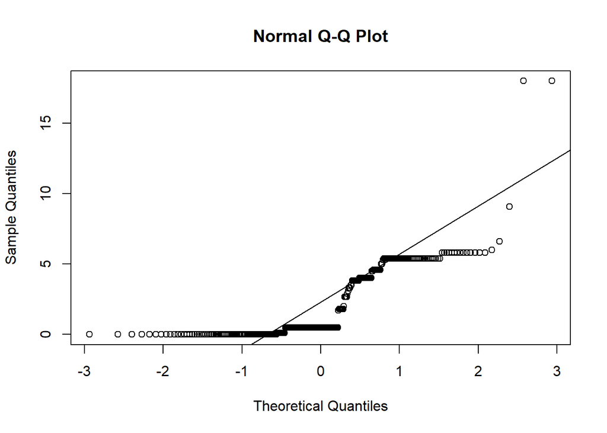

```r
mediana_grasas_sat <- median(datos$grasas_saturadas_gramos, na.rm = TRUE)
datos$grasas_saturadas_gramos[is.na(datos$grasas_saturadas_gramos)] <- mediana_grasas_sat

qqnorm(datos$grasas_saturadas_gramos)

qqline(datos$grasas_saturadas_gramos)
```

### Columna de grasas trans

Hay muy poca normalidad

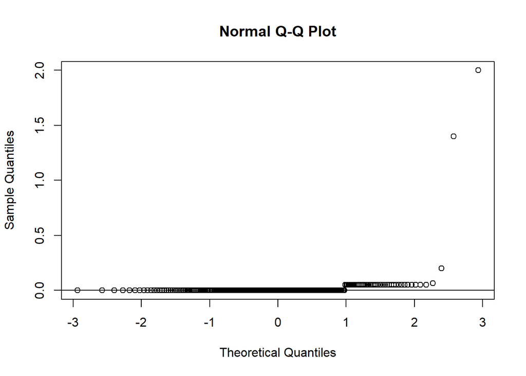

```r
mediana_grasas_trans <- median(datos$grasas_trans_gramos, na.rm = TRUE)
datos$grasas_trans_gramos[is.na(datos$grasas_trans_gramos)] <- mediana_grasas_trans

qqnorm(datos$grasas_trans_gramos)

qqline(datos$grasas_trans_gramos)
```

### Columna de proteína

No hay normalidad

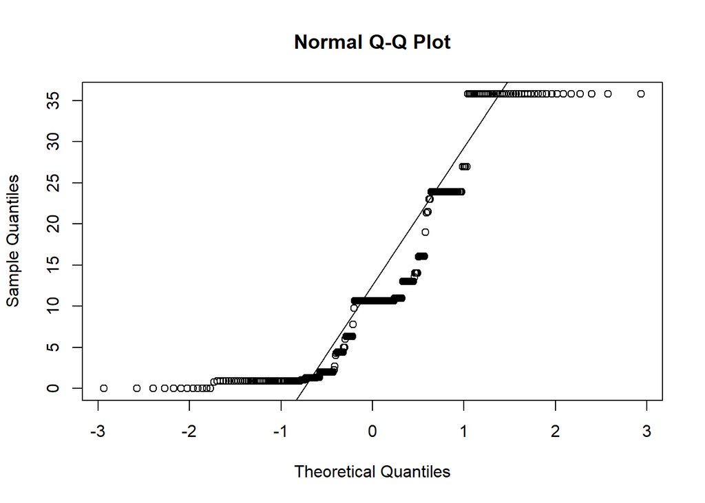

```r
mediana_prot <- median(datos$proteina_gramos, na.rm = TRUE)
datos$proteina_gramos[is.na(datos$proteina_gramos)] <- mediana_prot

qqnorm(datos$proteina_gramos)

qqline(datos$proteina_gramos)
```

### Columna de sodio

No hay normalidad

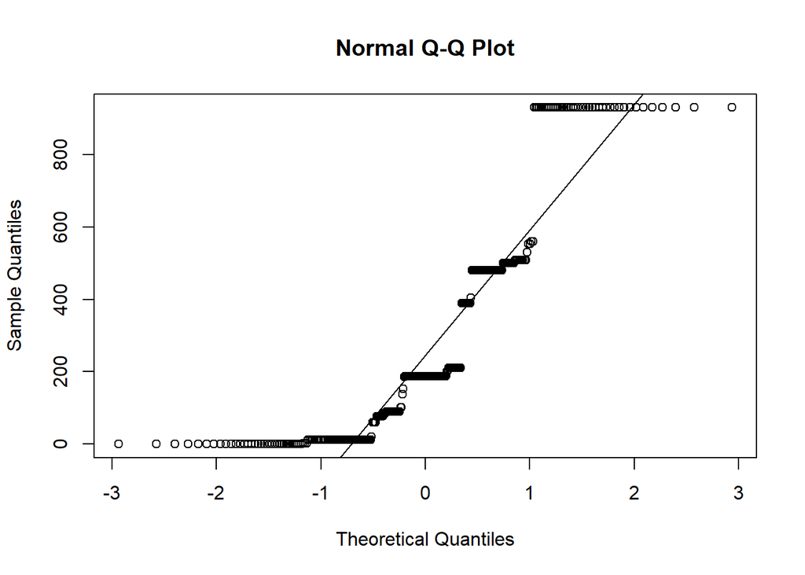

```r
mediana_sodio <- median(datos$sodio_miligramos, na.rm = TRUE)
datos$sodio_miligramos[is.na(datos$sodio_miligramos)] <- mediana_sodio

qqnorm(datos$sodio_miligramos)

qqline(datos$sodio_miligramos)
```

### Columna de azúcares

No hay normalidad

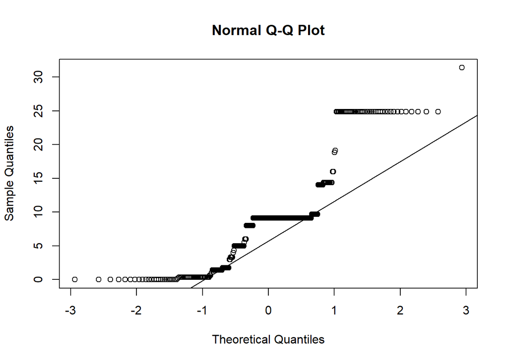

```r
mediana_azuc <- median(datos$azucares_gramos, na.rm = TRUE)
datos$azucares_gramos[is.na(datos$azucares_gramos)] <- mediana_azuc

qqnorm(datos$azucares_gramos)

qqline(datos$azucares_gramos)
```

### Columna de fibra

No hay normalidad

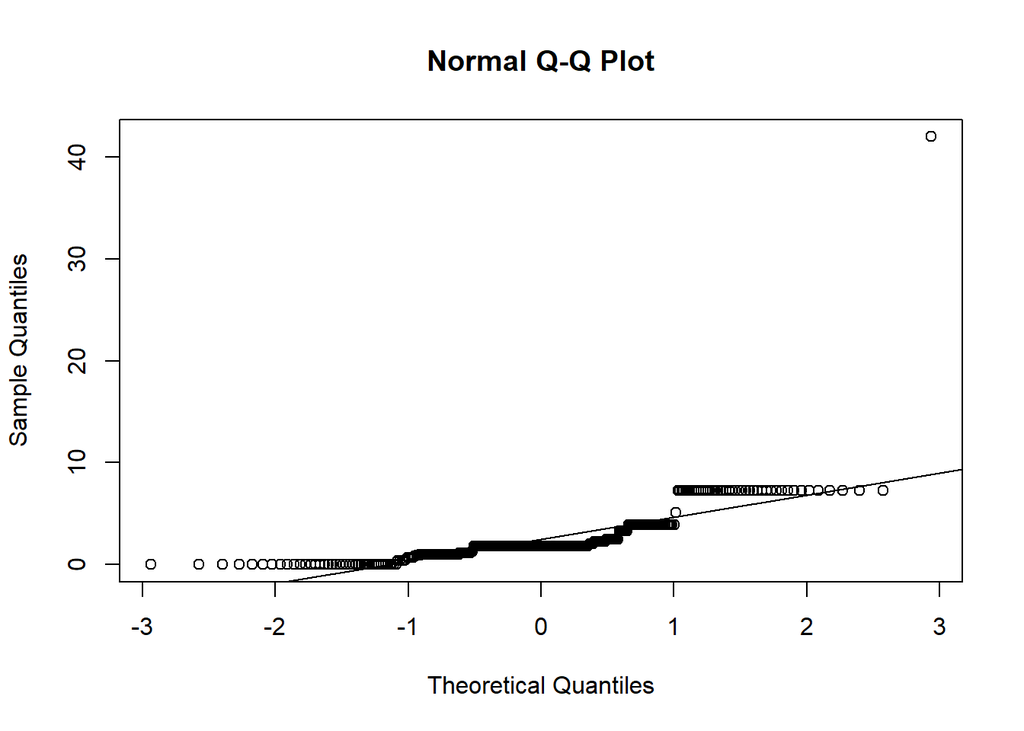

```r
mediana_fib <- median(datos$fibra_gramos, na.rm = TRUE)
datos$fibra_gramos[is.na(datos$fibra_gramos)] <- mediana_fib

qqnorm(datos$fibra_gramos)

qqline(datos$fibra_gramos)
```

### Columna de potasio

No hay normalidad

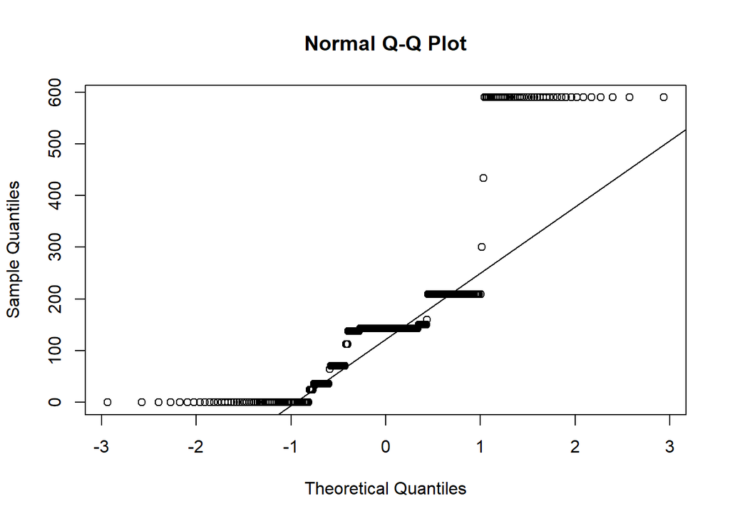

```r
mediana_pot <- median(datos$potasio_miligramos, na.rm = TRUE)
datos$potasio_miligramos[is.na(datos$potasio_miligramos)] <- mediana_pot

qqnorm(datos$potasio_miligramos)

qqline(datos$potasio_miligramos)
```

### Columna de calcio

No hay normalidad

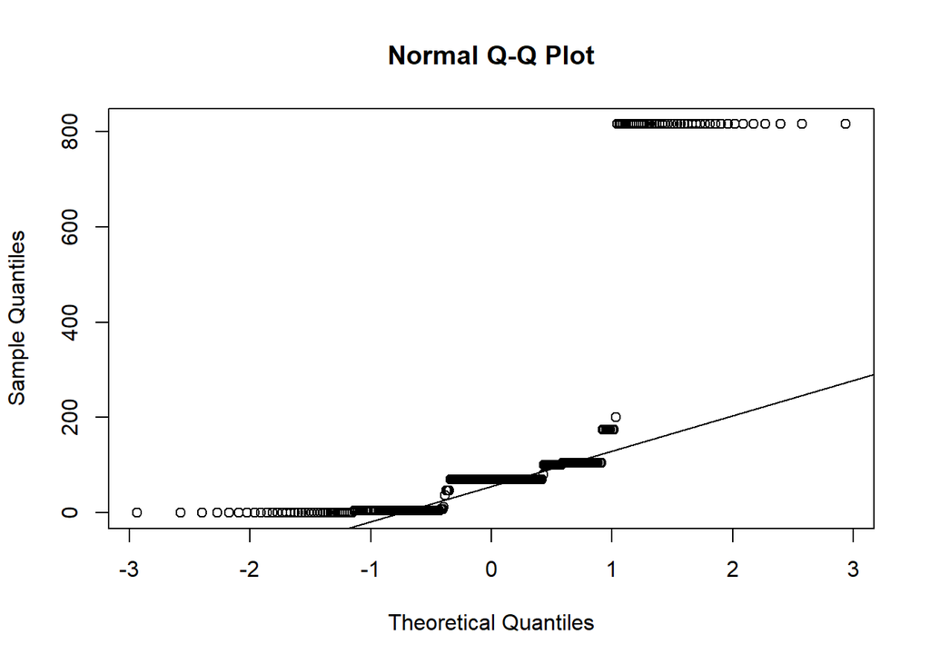

```r
mediana_calc <- median(datos$calcio_miligramos, na.rm = TRUE)
datos$calcio_miligramos[is.na(datos$calcio_miligramos)] <- mediana_calc

qqnorm(datos$calcio_miligramos)

qqline(datos$calcio_miligramos)
```

### Columna de hierro

No hay normalidad

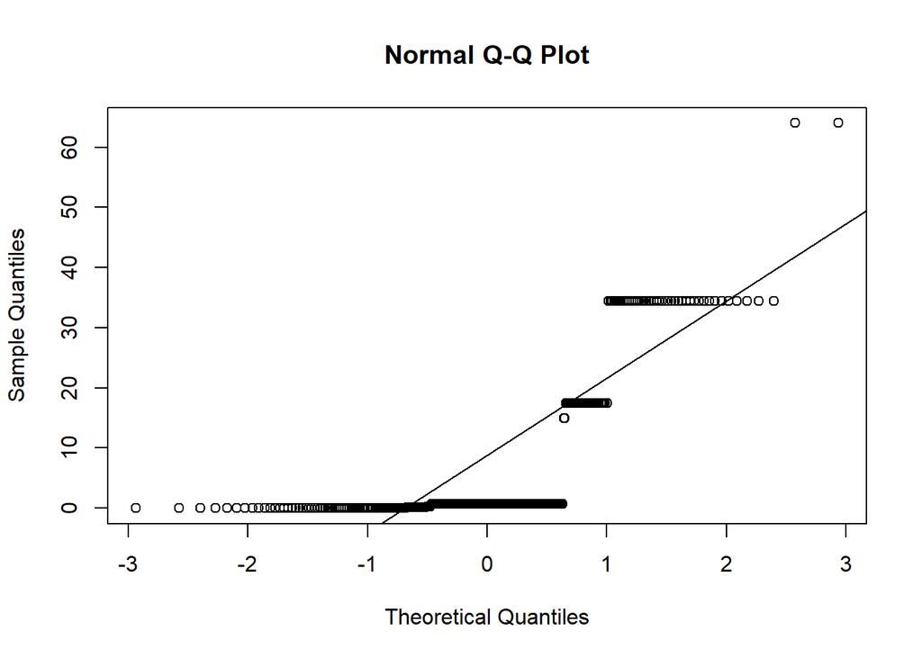

```r
mediana_hie <- median(datos$hierro_miligramos, na.rm = TRUE)
datos$hierro_miligramos[is.na(datos$hierro_miligramos)] <- mediana_hie

qqnorm(datos$hierro_miligramos)

qqline(datos$hierro_miligramos)
```

### Columna de vitamina A

No hay normalidad

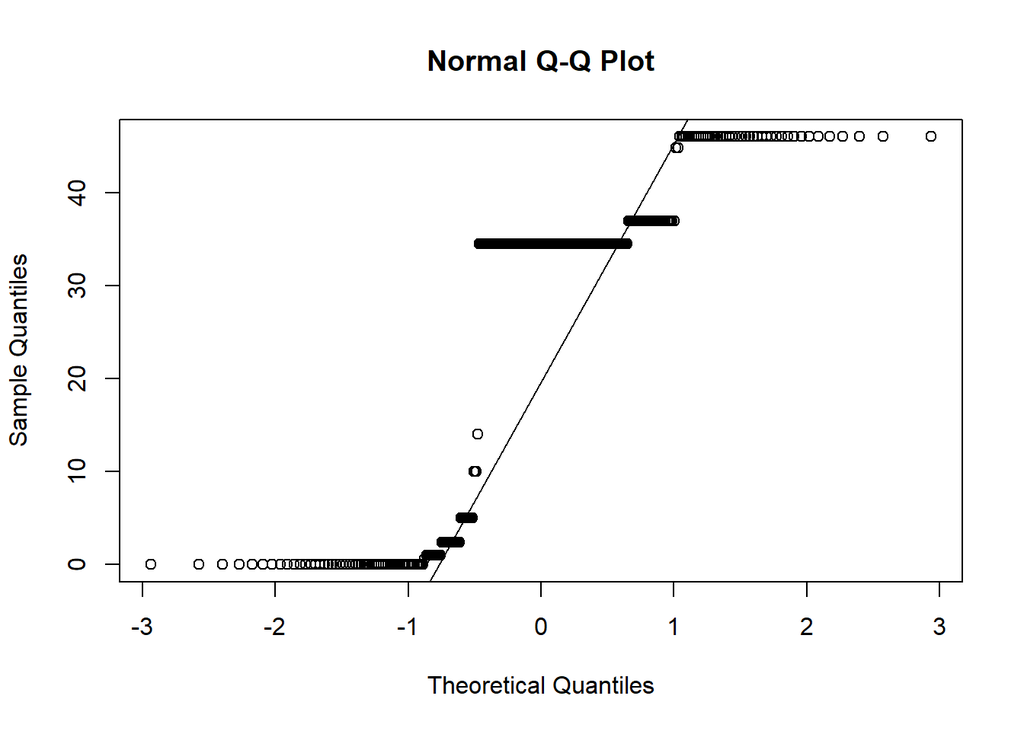

```r
mediana_vita <- median(datos$vitamina_a_mg, na.rm = TRUE)
datos$vitamina_a_mg[is.na(datos$vitamina_a_mg)] <- mediana_vita

qqnorm(datos$vitamina_a_mg)

qqline(datos$vitamina_a_mg)
```

### Columna de vitamina C

No hay normalidad

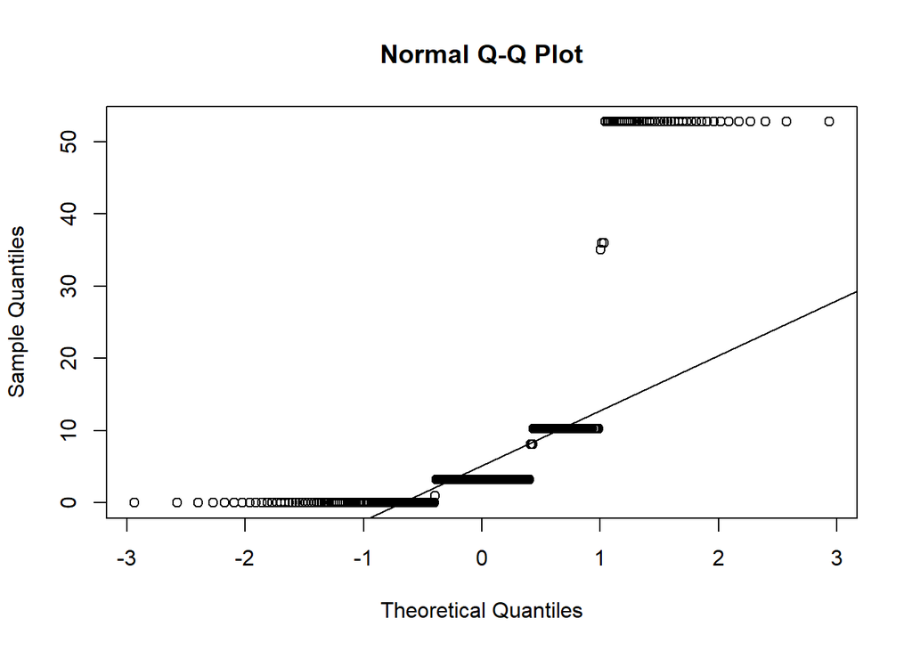

```r
mediana_vitc <- median(datos$vitamina_c_mg, na.rm = TRUE)
datos$vitamina_c_mg[is.na(datos$vitamina_c_mg)] <- mediana_vitc

qqnorm(datos$vitamina_c_mg)

qqline(datos$vitamina_c_mg)
```

### Columna de vitamina d

No hay normalidad

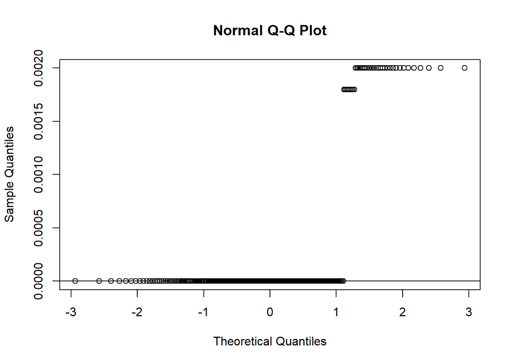

```r
mediana_vitd <- median(datos$vitamina_d_mg, na.rm = TRUE)
datos$vitamina_d_mg[is.na(datos$vitamina_d_mg)] <- mediana_vitd

qqnorm(datos$vitamina_d_mg)

qqline(datos$vitamina_d_mg)
```

### Columna de porciones por envase

Hay muy poca normalidad

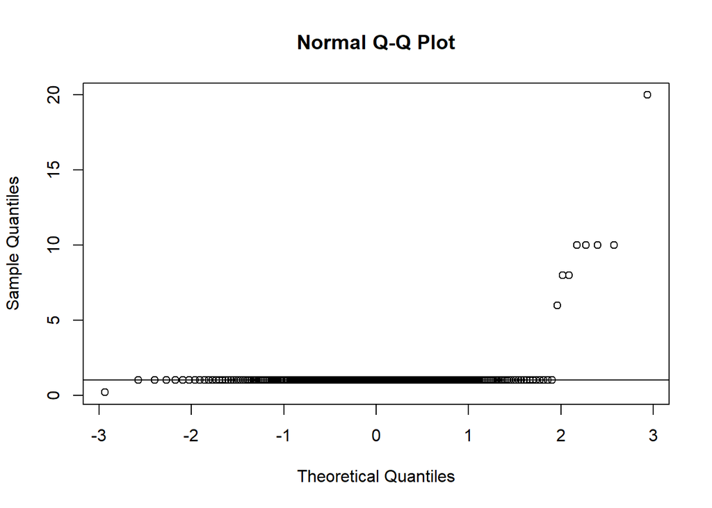

```r
mediana_porc <- median(datos$porciones_por_envase, na.rm = TRUE)
datos$porciones_por_envase[is.na(datos$porciones_por_envase)] <- mediana_porc

qqnorm(datos$porciones_por_envase)

qqline(datos$porciones_por_envase)
```

### Columna de tamaño de la porción

No hay normalidad

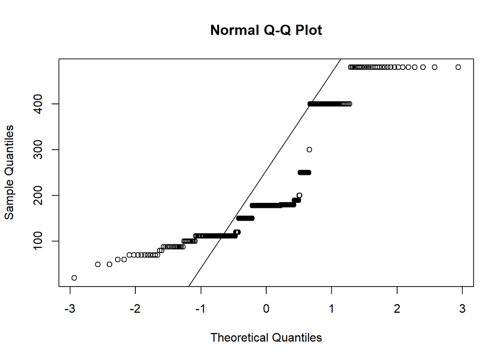

```r
mediana_tam <- median(datos$tamano_de_la_porcion_gramos, na.rm = TRUE)
datos$tamano_de_la_porcion_gramos[is.na(datos$tamano_de_la_porcion_gramos)] <- mediana_tam

qqnorm(datos$tamano_de_la_porcion_gramos)

qqline(datos$tamano_de_la_porcion_gramos)
```

## Transformación de variables Box-Cox

Esto lo haremos para aquellas variables que vamos a usar en el análisis: calorías, carbohidratos, colesterol, grasas totales, proteína, sodio, azúcares, fibra, potasio y calcio. Una vez hecha la transformación, se compararán los histogramas del antes y el después.

### Box-Cox usando forecast

#### Calorías

```r
library(forecast)
lambda_opt <- BoxCox.lambda(datos$calorias_kcal)
lambda_opt
```

```
## [1] -0.1049599
```

```r
calorias_transf <- BoxCox(datos$calorias_kcal,lambda_opt)
```

Ahora comparamos los histogramas del antes y después de la transformación

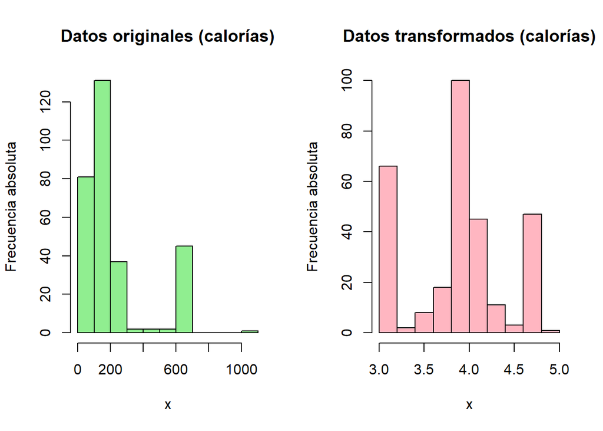

```r
par(mfrow=c(1,2))
hist(datos$calorias_kcal,col="lightgreen",main="Datos originales (calorías)",
     xlab="x",ylab="Frecuencia absoluta")

hist(calorias_transf,col="lightpink",main="Datos transformados (calorías)",
     xlab="x",ylab="Frecuencia absoluta")
```

Como podemos ver, ya hay más normalidad que antes

Hacemos una prueba de hipótesis

```r
shapiro.test(datos$calorias_kcal)
```

```
##
##  Shapiro-Wilk normality test
##
## data:  datos$calorias_kcal
## W = 0.7444, p-value < 2.2e-16
```

```r
shapiro.test(calorias_transf)
```

```
##
##  Shapiro-Wilk normality test
##
## data:  calorias_transf
## W = 0.89748, p-value = 2.133e-13
```

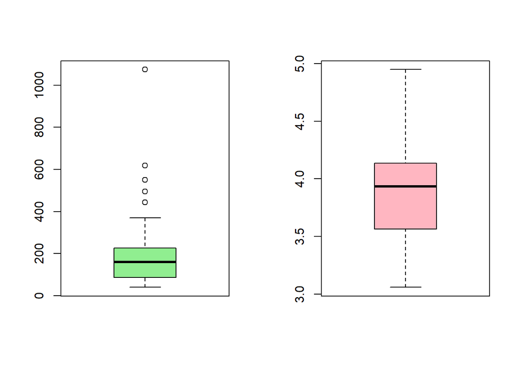

```r
par(mfrow=c(1,2))
boxplot(datos$calorias_kcal,col="lightgreen")
boxplot(calorias_transf,col="lightpink")
```

Como podemos observar, al hacer la transformación de los datos ya no nos muestra datos atípicos. Además, el valor p al momento de hacer la transformación aumenta. En este caso nos vamos a quedar con las calorías transformadas

#### Carbohidratos

```r
lambda_opt_carbs <- BoxCox.lambda(datos$carbohidratos_gramos)
lambda_opt_carbs
```

```
## [1] -0.1368777
```

```r
carbs_transf <- BoxCox(datos$carbohidratos_gramos, lambda_opt_carbs)
```

Ahora comparamos los histogramas del antes y después de la transformación

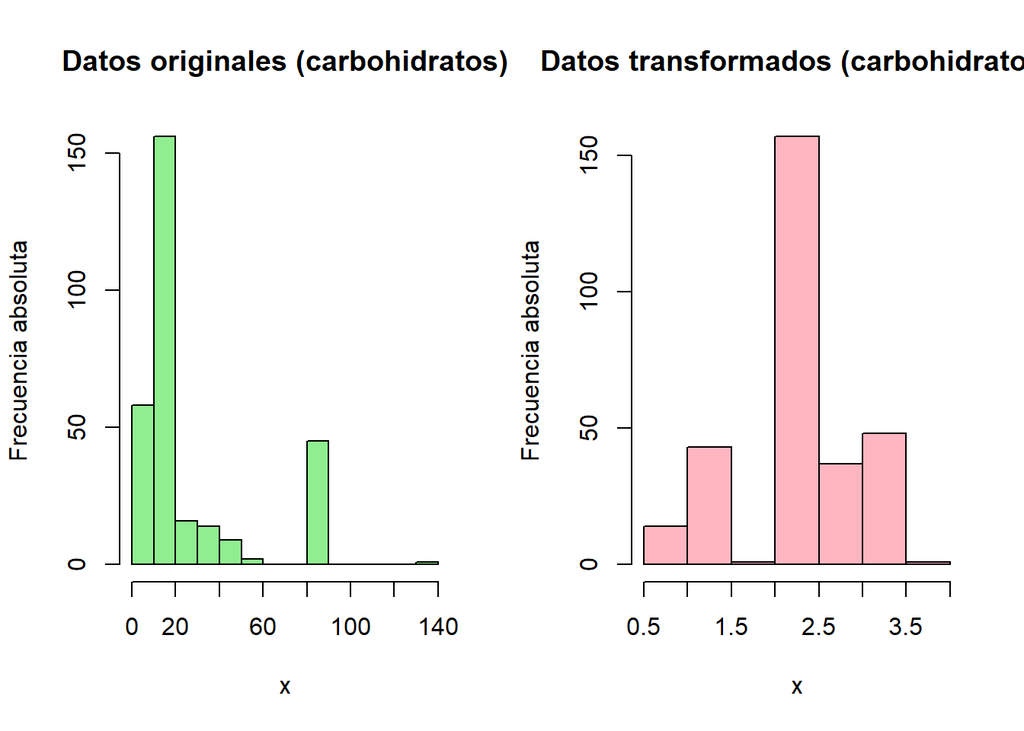

```r
par(mfrow=c(1,2))
hist(datos$carbohidratos_gramos,col="lightgreen",main="Datos originales (carbohidratos)",
     xlab="x",ylab="Frecuencia absoluta")

hist(carbs_transf,col="lightpink",main="Datos transformados (carbohidratos)",
     xlab="x",ylab="Frecuencia absoluta")
```

Muestra un poco más de normalidad, sin embargo no lo es al 100%

Hacemos una prueba de hipótesis

```r
shapiro.test(datos$carbohidratos_gramos)
```

```
##
##  Shapiro-Wilk normality test
##
## data:  datos$carbohidratos_gramos
## W = 0.69043, p-value < 2.2e-16
```

```r
shapiro.test(carbs_transf)
```

```
##
##  Shapiro-Wilk normality test
##
## data:  carbs_transf
## W = 0.91688, p-value = 7.167e-12
```

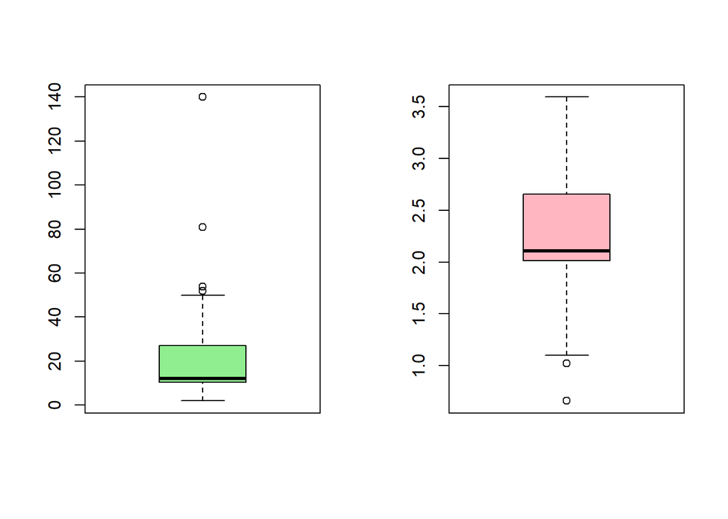

```r
par(mfrow=c(1,2))
boxplot(datos$carbohidratos_gramos,col="lightgreen")
boxplot(carbs_transf,col="lightpink")
```

En este caso aún hay datos atípicos en los carbohidratos, sin embargo son menos que los que habían antes de la transformación. El valor p aumenta al hacer la transformación, lo cual indica que es buena opción quedarnos con esta transformación.

### Colesterol

```r
lambda_opt_col <- BoxCox.lambda(datos$colesterol_miligramos)
lambda_opt_col
```

```
## [1] 0.02988835
```

```r
col_transf <- BoxCox(datos$colesterol_miligramos, lambda_opt_col)
```

Ahora comparamos los histogramas del antes y después de la transformación

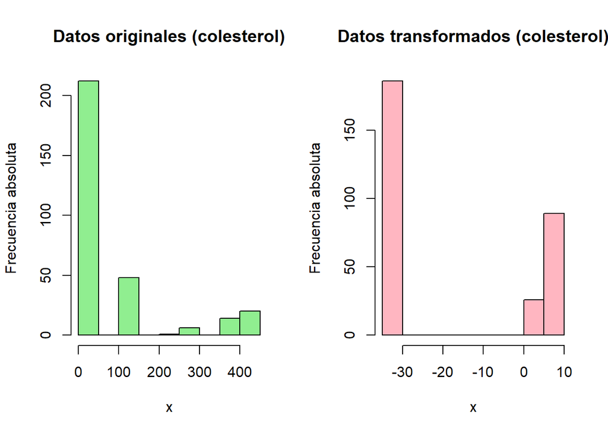

```r
par(mfrow=c(1,2))
hist(datos$colesterol_miligramos,col="lightgreen",main="Datos originales (colesterol)",
     xlab="x",ylab="Frecuencia absoluta")

hist(col_transf,col="lightpink",main="Datos transformados (colesterol)",
     xlab="x",ylab="Frecuencia absoluta")
```

En este caso ocurre algo distinto a las variables anteriores, ya que al momento de hacer la transformación nos da unos valores negativos, y en la vida real no existen medidas de colesterol negativo.

Hacemos una prueba de hipótesis

```r
shapiro.test(datos$colesterol_miligramos)
```

```
##
##  Shapiro-Wilk normality test
##
## data:  datos$colesterol_miligramos
## W = 0.57497, p-value < 2.2e-16
```

```r
shapiro.test(col_transf)
```

```
##
##  Shapiro-Wilk normality test
##
## data:  col_transf
## W = 0.63515, p-value < 2.2e-16
```

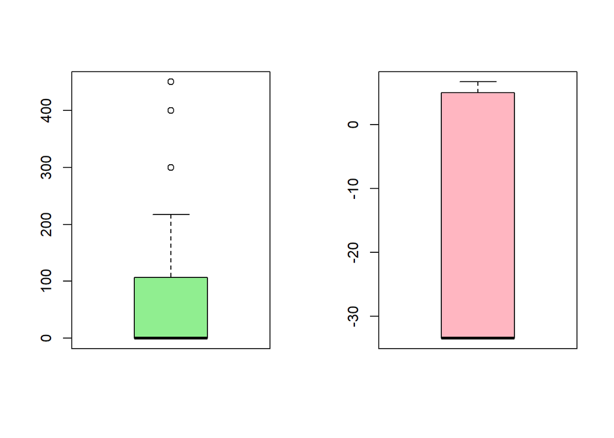

```r
par(mfrow=c(1,2))
boxplot(datos$colesterol_miligramos,col="lightgreen")
boxplot(col_transf,col="lightpink")
```

Con la transformaación ya no hay datos atípicos. Sin embargo, el valor p se queda igual. Al hacer la transformación algunos datos son negativos, por lo cual vamos a quedarnos con los datos sin transformar

### Grasas totales

```r
lambda_opt_grasas <- BoxCox.lambda(datos$grasas_totales_gramos)
lambda_opt_grasas
```

```
## [1] 0.1355813
```

```r
grasas_transf <- BoxCox(datos$grasas_totales_gramos, lambda_opt_grasas)
```

Es probable que el caso del colesterol se repita para las grasas totales

Ahora comparamos los histogramas del antes y después de la transformación

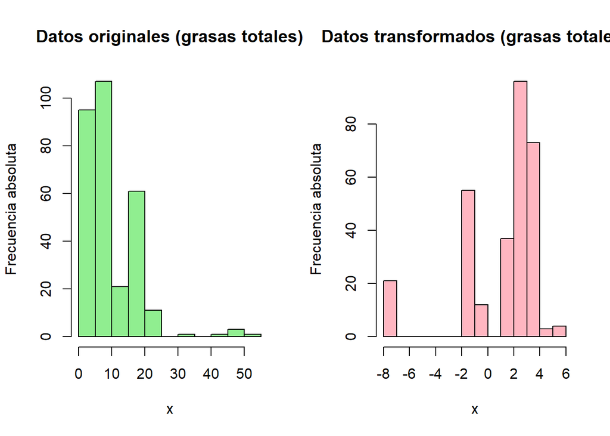

```r
par(mfrow=c(1,2))
hist(datos$grasas_totales_gramos,col="lightgreen",main="Datos originales (grasas totales)",
     xlab="x",ylab="Frecuencia absoluta")

hist(grasas_transf,col="lightpink",main="Datos transformados (grasas totales)",
     xlab="x",ylab="Frecuencia absoluta")
```

Nuestra hipótesis fue correcta, ya que así como en el caso del colesterol, al hacer la transformación salieron valores negativos.

Ahora hacemos una comparación con la caja de bigotes y hacemos un shapiro test

```r
shapiro.test(datos$grasas_totales_gramos)
```

```
##
##  Shapiro-Wilk normality test
##
## data:  datos$grasas_totales_gramos
## W = 0.80189, p-value < 2.2e-16
```

```r
shapiro.test(grasas_transf)
```

```
##
##  Shapiro-Wilk normality test
##
## data:  grasas_transf
## W = 0.76801, p-value < 2.2e-16
```

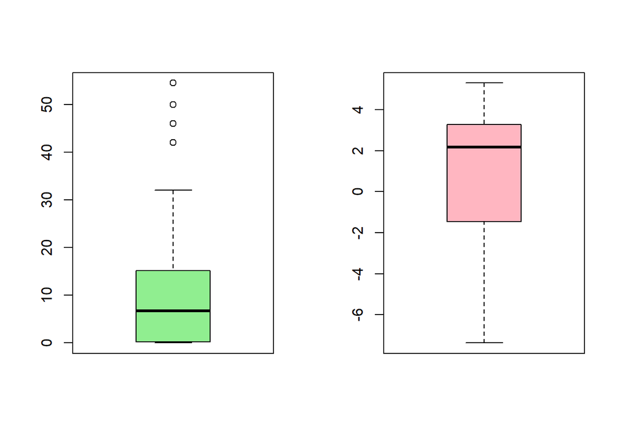

```r
par(mfrow=c(1,2))
boxplot(datos$grasas_totales_gramos,col="lightgreen")
boxplot(grasas_transf,col="lightpink")
```

Al hacer la transformación ya no hay valores atípicos. El valor p es el mismo antes y después de la transformación. Al hacer la transformación algunos datos son negativos, por lo cual vamos a quedarnos con los datos sin transformar

### Proteína

```r
lambda_opt_prot <- BoxCox.lambda(datos$proteina_gramos)
lambda_opt_prot
```

```
## [1] 0.02373072
```

```r
prot_transf <- BoxCox(datos$proteina_gramos, lambda_opt_col)
```

Para el caso de la proteína ocurrirá lo mismo que con el colesterol y las grasas totales ya que nos dio como resultado un valor positivo

Ahora comparamos los histogramas del antes y después de la transformación

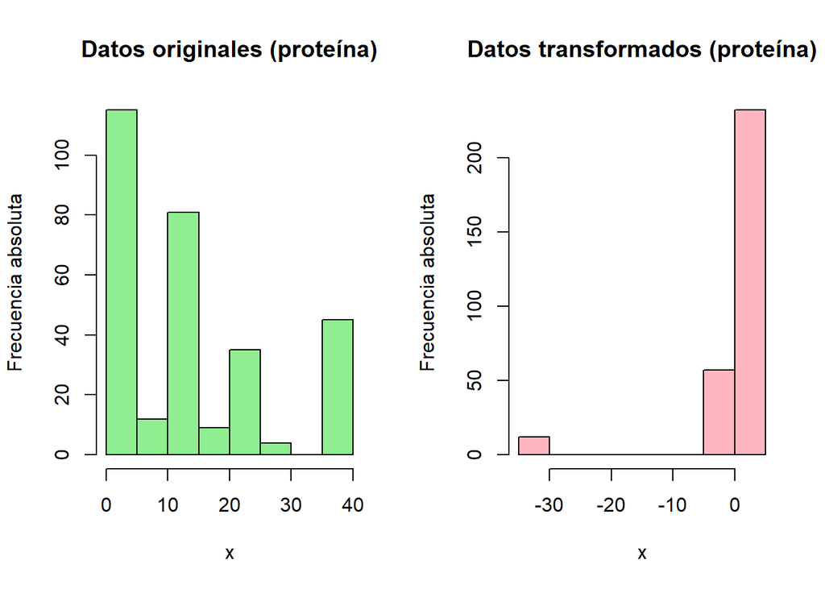

```r
par(mfrow=c(1,2))
hist(datos$proteina_gramos,col="lightgreen",main="Datos originales (proteína)",
     xlab="x",ylab="Frecuencia absoluta")

hist(prot_transf,col="lightpink",main="Datos transformados (proteína)",
     xlab="x",ylab="Frecuencia absoluta")
```

No se ve normalidad

Ahora hacemos una comparación con la caja de bigotes y hacemos un shapiro test

```r
shapiro.test(datos$proteina_gramos)
```

```
##
##  Shapiro-Wilk normality test
##
## data:  datos$proteina_gramos
## W = 0.83721, p-value < 2.2e-16
```

```r
shapiro.test(prot_transf)
```

```
##
##  Shapiro-Wilk normality test
##
## data:  prot_transf
## W = 0.35244, p-value < 2.2e-16
```

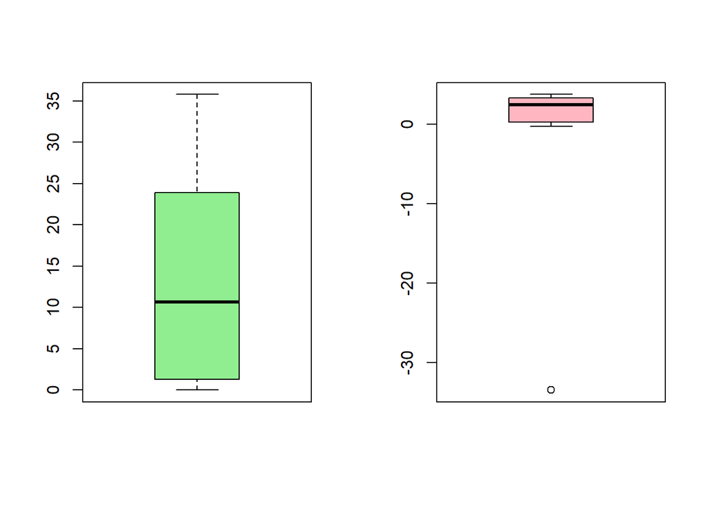

```r
par(mfrow=c(1,2))
boxplot(datos$proteina_gramos,col="lightgreen")
boxplot(prot_transf,col="lightpink")
```

Al hacer la transformación nos encontramos con un dato atípico. El valor p se quedó igual. En este caso nos quedaremos con los datos sin transformar

### Sodio

```r
lambda_opt_sodio <- BoxCox.lambda(datos$sodio_miligramos)
lambda_opt_sodio
```

```
## [1] 0.02380327
```

```r
sodio_transf <- BoxCox(datos$sodio_miligramos, lambda_opt_sodio)
```

Aquí también ocurrirá lo mismo que en los últimos tres casos

Ahora comparamos los histogramas del antes y después de la transformación

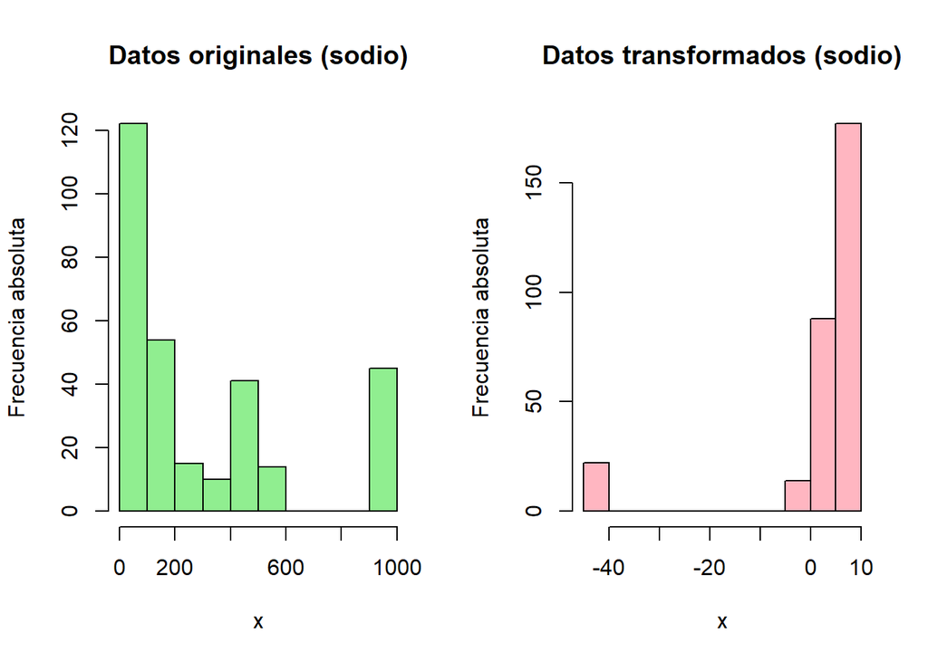

```r
par(mfrow=c(1,2))
hist(datos$sodio_miligramos,col="lightgreen",main="Datos originales (sodio)",
     xlab="x",ylab="Frecuencia absoluta")

hist(sodio_transf,col="lightpink",main="Datos transformados (sodio)",
     xlab="x",ylab="Frecuencia absoluta")
```

No se ve normalidad

Ahora hacemos una comparación con la caja de bigotes y hacemos un shapiro test

```r
shapiro.test(datos$sodio_miligramos)
```

```
##
##  Shapiro-Wilk normality test
##
## data:  datos$sodio_miligramos
## W = 0.80492, p-value < 2.2e-16
```

```r
shapiro.test(sodio_transf)
```

```
##
##  Shapiro-Wilk normality test
##
## data:  sodio_transf
## W = 0.4193, p-value < 2.2e-16
```

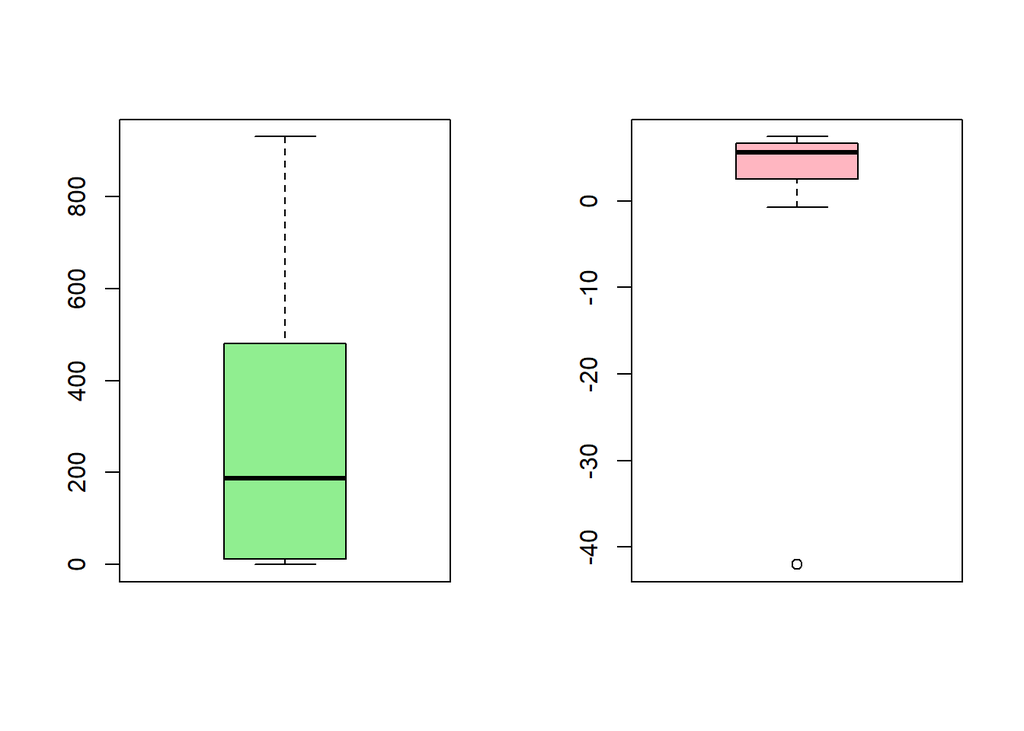

```r
par(mfrow=c(1,2))
boxplot(datos$sodio_miligramos,col="lightgreen")
boxplot(sodio_transf,col="lightpink")
```

Esta transformación nos generó un dato atípico. El valor p se quedó igual. Nos quedaremos con los datos sin transformar.

### Azúcares

```r
lambda_opt_azuc <- BoxCox.lambda(datos$azucares_gramos)
lambda_opt_azuc
```

```
## [1] 0.08172285
```

```r
azuc_transf <- BoxCox(datos$azucares_gramos, lambda_opt_azuc)
```

Ahora comparamos los histogramas del antes y después de la transformación

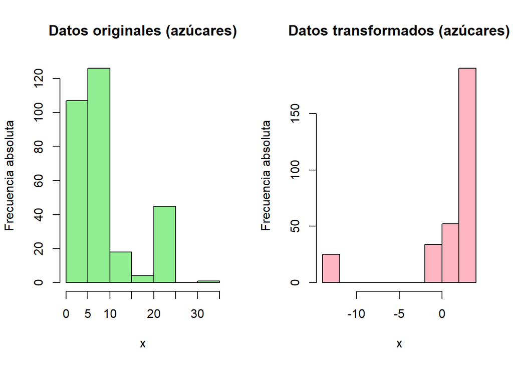

```r
par(mfrow=c(1,2))
hist(datos$azucares_gramos,col="lightgreen",main="Datos originales (azúcares)",
     xlab="x",ylab="Frecuencia absoluta")

hist(azuc_transf,col="lightpink",main="Datos transformados (azúcares)",
     xlab="x",ylab="Frecuencia absoluta")
```

No se ve normalidad

Ahora hacemos una comparación con la caja de bigotes y hacemos un shapiro test

```r
shapiro.test(datos$azucares_gramos)
```

```
##
##  Shapiro-Wilk normality test
##
## data:  datos$azucares_gramos
## W = 0.83909, p-value < 2.2e-16
```

```r
shapiro.test(azuc_transf)
```

```
##
##  Shapiro-Wilk normality test
##
## data:  azuc_transf
## W = 0.57832, p-value < 2.2e-16
```

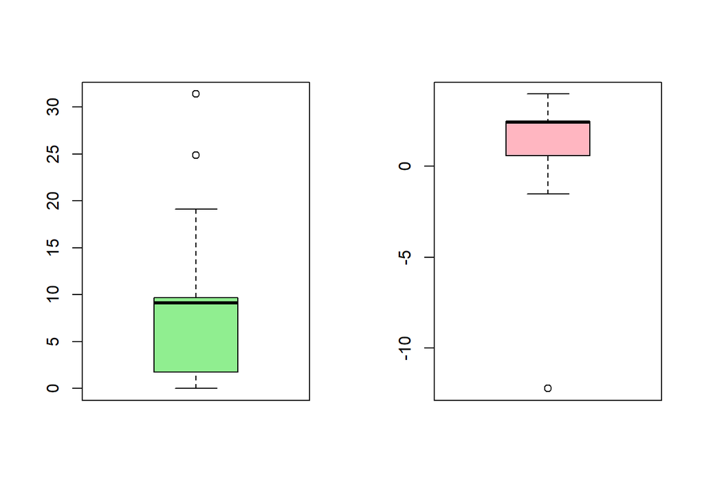

```r
par(mfrow=c(1,2))
boxplot(datos$azucares_gramos,col="lightgreen")
boxplot(azuc_transf,col="lightpink")
```

```r
lambda_opt_fibra <- BoxCox.lambda(datos$fibra_gramos)
lambda_opt_fibra
```

```
## [1] 0.1360729
```

```r
fibra_transf <- BoxCox(datos$fibra_gramos, lambda_opt_fibra)
```

Ahora comparamos los histogramas del antes y después de la transformación

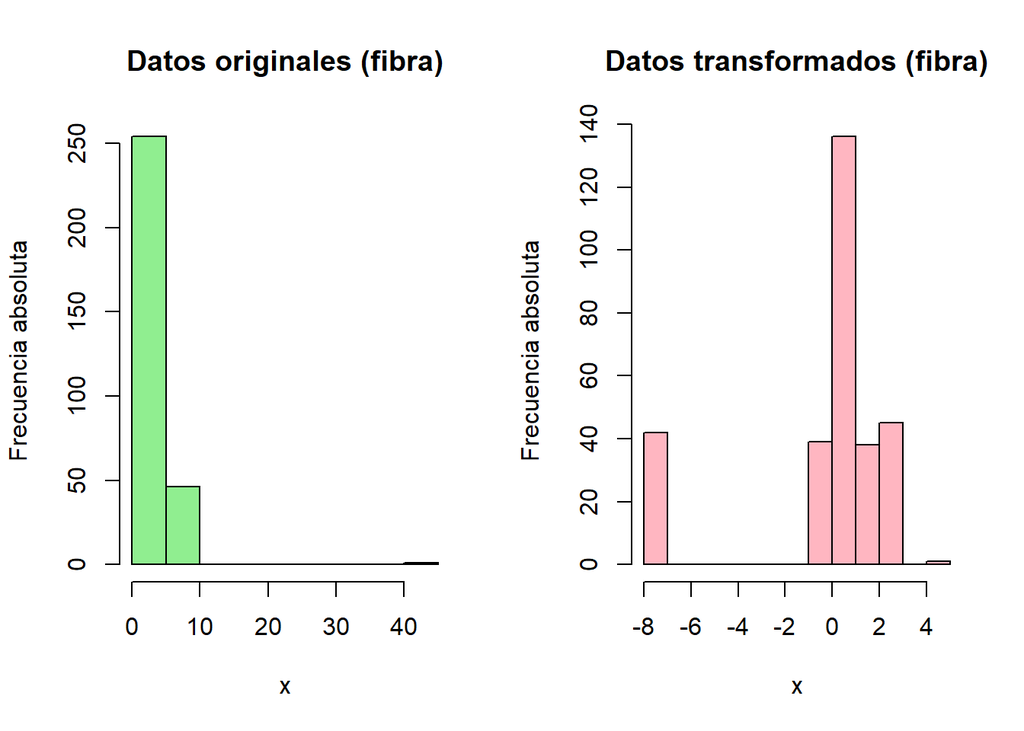

```r
par(mfrow=c(1,2))
hist(datos$fibra_gramos,col="lightgreen",main="Datos originales (fibra)",
     xlab="x",ylab="Frecuencia absoluta")

hist(fibra_transf,col="lightpink",main="Datos transformados (fibra)",
     xlab="x",ylab="Frecuencia absoluta")
```

Al hacer la transformación está más cerca de verse normal

Ahora hacemos una comparación con la caja de bigotes y hacemos un shapiro test

```r
shapiro.test(datos$fibra_gramos)
```

```
##
##  Shapiro-Wilk normality test
##
## data:  datos$fibra_gramos
## W = 0.55822, p-value < 2.2e-16
```

```r
shapiro.test(fibra_transf)
```

```
##
##  Shapiro-Wilk normality test
##
## data:  fibra_transf
## W = 0.64363, p-value < 2.2e-16
```

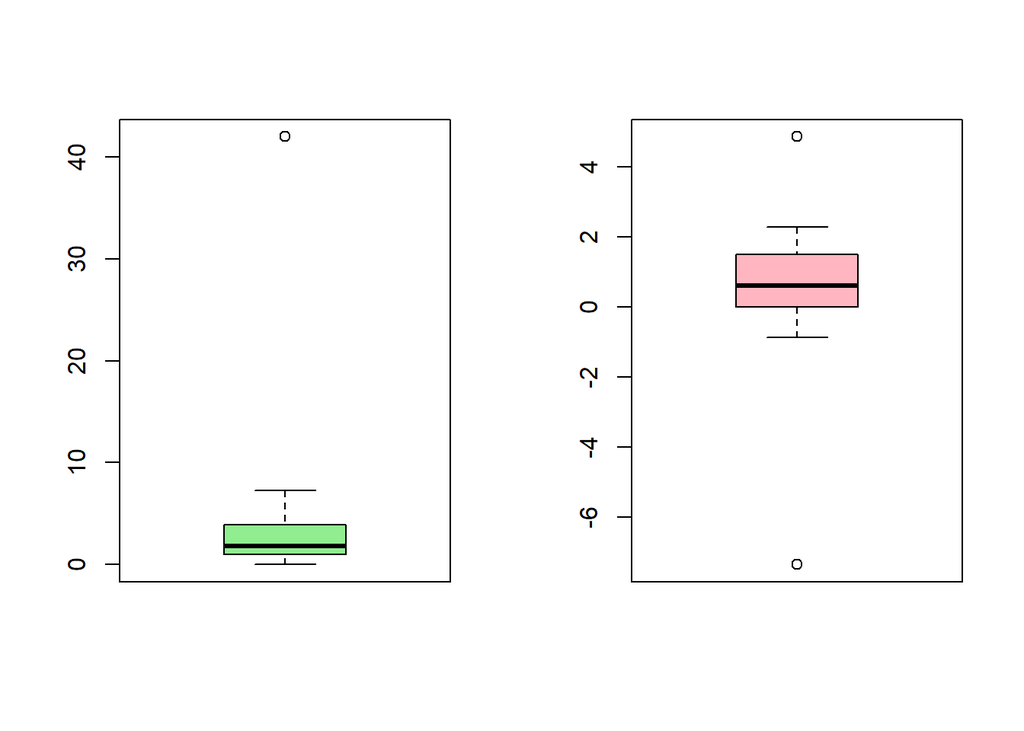

```r
par(mfrow=c(1,2))
boxplot(datos$fibra_gramos,col="lightgreen")
boxplot(fibra_transf,col="lightpink")
```

Ahora hay un dato atípico más después de hacer la transformación. El valor p se quedó igual. Nos quedaremos con los datos sin transformar.

### Potasio

```r
lambda_opt_pot <- BoxCox.lambda(datos$potasio_miligramos)
lambda_opt_pot
```

```
## [1] 0.08873022
```

```r
pot_transf <- BoxCox(datos$potasio_miligramos, lambda_opt_pot)
```

Ahora comparamos los histogramas del antes y después de la transformación

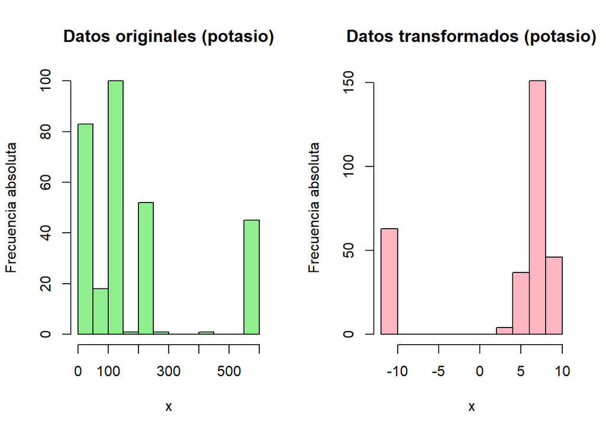

```r
par(mfrow=c(1,2))
hist(datos$potasio_miligramos,col="lightgreen",main="Datos originales (potasio)",
     xlab="x",ylab="Frecuencia absoluta")

hist(pot_transf,col="lightpink",main="Datos transformados (potasio)",
     xlab="x",ylab="Frecuencia absoluta")
```

Ahora hacemos una comparación con la caja de bigotes y hacemos un shapiro test

```r
shapiro.test(datos$potasio_miligramos)
```

```
##
##  Shapiro-Wilk normality test
##
## data:  datos$potasio_miligramos
## W = 0.7537, p-value < 2.2e-16
```

```r
shapiro.test(pot_transf)
```

```
##
##  Shapiro-Wilk normality test
##
## data:  pot_transf
## W = 0.62514, p-value < 2.2e-16
```

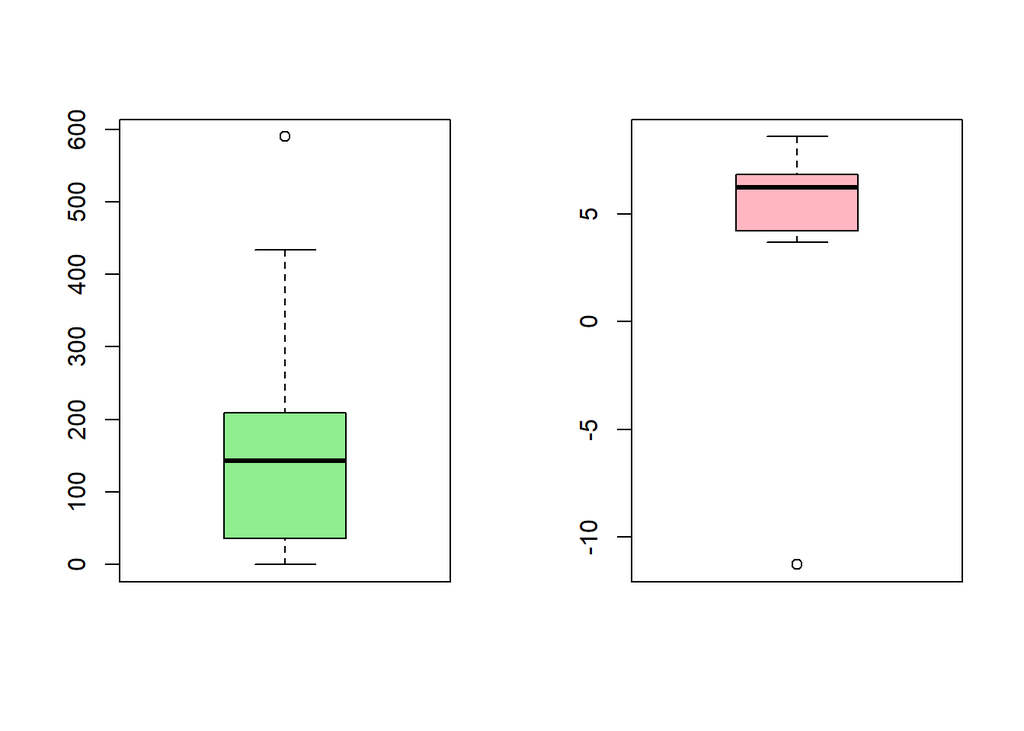

```r
par(mfrow=c(1,2))
boxplot(datos$potasio_miligramos,col="lightgreen")
boxplot(pot_transf,col="lightpink")
```

Esta vez en vez de que el dato atípico sea un valor muy grande, el dato atípico es un valor muy pequeño. El valor p se quedó igual. Vamos a usar los datos sin transformar

### Calcio

```r
lambda_opt_calc <- BoxCox.lambda(datos$calcio_miligramos)
lambda_opt_calc
```

```
## [1] 0.01500116
```

```r
calc_transf <- BoxCox(datos$calcio_miligramos, lambda_opt_calc)
```

Ahora comparamos los histogramas del antes y después de la transformación

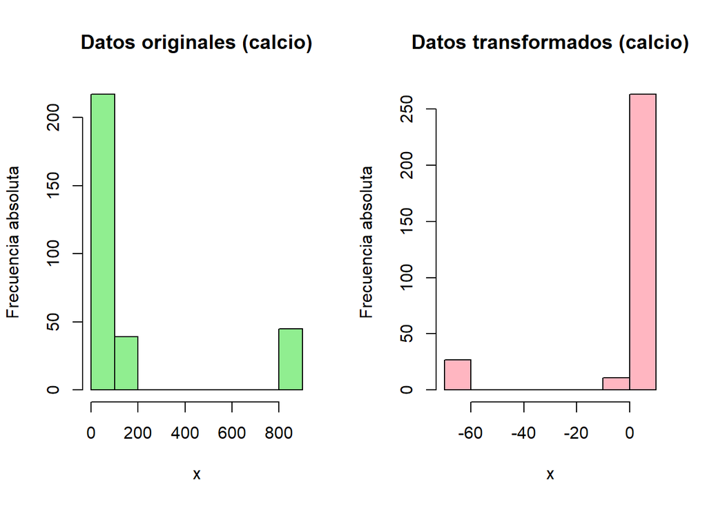

```r
par(mfrow=c(1,2))
hist(datos$calcio_miligramos,col="lightgreen",main="Datos originales (calcio)",
     xlab="x",ylab="Frecuencia absoluta")

hist(calc_transf,col="lightpink",main="Datos transformados (calcio)",
     xlab="x",ylab="Frecuencia absoluta")
```

No se ve cerca de ser normal

Ahora hacemos una comparación con la caja de bigotes y hacemos un shapiro test

```r
shapiro.test(datos$calcio_miligramos)
```

```
##
##  Shapiro-Wilk normality test
##
## data:  datos$calcio_miligramos
## W = 0.55436, p-value < 2.2e-16
```

```r
shapiro.test(calc_transf)
```

```
##
##  Shapiro-Wilk normality test
##
## data:  calc_transf
## W = 0.40723, p-value < 2.2e-16
```

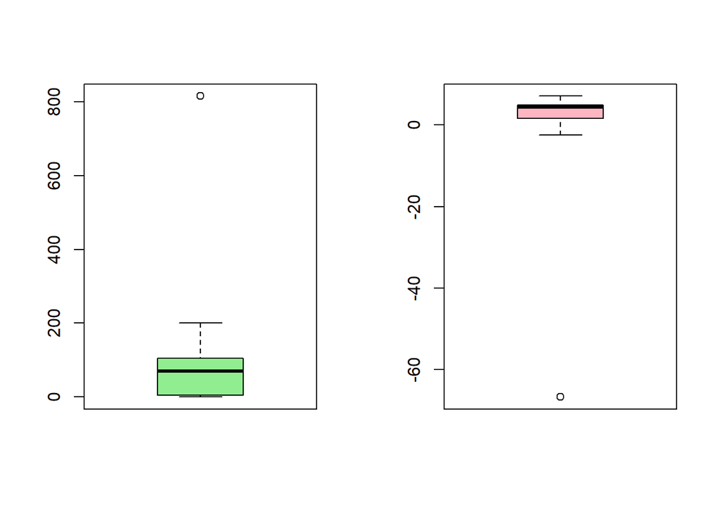

```r
par(mfrow=c(1,2))
boxplot(datos$calcio_miligramos,col="lightgreen")
boxplot(calc_transf,col="lightpink")
```

Como pasó con el potasio, ahora en vez de tener un valor típico máximo, ahora hay uno mínimo. El valor p se quedó igual. Vamos a usar los datos sin transformar

Vamos a usar la variable producto como factor, así que hacemos la transformación. Esto con la finalidad de poder analizar la relación de las calorías con el producto

```r
comida<- as.factor(datos$producto)
```

Ahora vamos a juntar todas estas nuevas variables en una sola tabla. Para esto necesitamos usar la función data.frame. Esto con la finalidad de después poder separar hacer dos grupos distintos: uno con calorías bajas y otro con calorías altas.

```r
datos2 <- data.frame(comida = comida, calorias = calorias_transf, carbohidratos =
                carbs_transf, colesterol = datos$colesterol_miligramos, grasas =
                datos$grasas_totales_gramos, proteina = datos$proteina_gramos, sodio =
                datos$sodio_miligramos, azucar = datos$azucares_gramos, fibra =
                datos$fibra_gramos, potasio = datos$potasio_miligramos, calcio =
                datos$calcio_miligramos)
str(datos2)
```

```
## 'data.frame':    301 obs. of  11 variables:
##  $ comida       : Factor w/ 37 levels "alitas","camarones_empanizados",..: 12 8 14 17 35 7 14 8 5 7 ...
##  $ calorias     : num  3.96 3.11 3.93 3.06 3.4 ...
##   ..- attr(*, "lambda")= num -0.105
##  $ carbohidratos: num  1.5 2.01 1.02 2.01 2.35 ...
##   ..- attr(*, "lambda")= num -0.137
##  $ colesterol   : num  450 0 0 0 0 ...
##  $ grasas       : num  11.4 0.2 5.8 0 0.2 ...
##  $ proteina     : num  10.7 0.9 23.9 0 0 ...
##  $ sodio        : num  390 12 480 1 2 ...
##  $ azucar       : num  1.76 9.1 0.33 8 16 24.9 0.33 9.1 9.7 24.9 ...
##  $ fibra        : num  1 1.8 3.92 2.5 0.9 7.3 3.92 1.8 1.1 7.3 ...
##  $ potasio      : num  143 209 0 70 0 ...
##  $ calcio       : num  70 4.98 105 0.08 0 ...
```

## Filtramos las calorías

```r
q25 <- quantile(datos2$calorias, probs=0.25)
q25
```

```
##      25%
## 3.565271
```

```r
calorias_bajas <- datos2[datos2$calorias<= q25,]

calorias_altas <- datos2[datos2$calorias>q25,]
```

# Fase 3

## Comparaciones

Haremos comparaciones entre los dos grupos de calorías con un intervalo de confianza del 96%

```r
# carbohidratos
compara_carbs <- t.test(calorias_altas$carbohidratos,calorias_bajas$carbohidratos, conf.level = 0.96, paired=F)

compara_carbs$conf.int
```

```
## [1] 0.03134209 0.26756267
## attr(,"conf.level")
## [1] 0.96
```

```r
# colesterol
compara_col <- t.test(calorias_altas$colesterol,calorias_bajas$colesterol, conf.level = 0.96, paired=F)

compara_col$conf.int
```

```
## [1]  77.86914 120.03131
## attr(,"conf.level")
## [1] 0.96
```

```r
# grasas totales
compara_grasas <- t.test(calorias_altas$grasas,calorias_bajas$grasas, conf.level = 0.96, paired=F)

compara_grasas$conf.int
```

```
## [1]  9.895151 12.095062
## attr(,"conf.level")
## [1] 0.96
```

```r
# proteína
compara_prot <- t.test(calorias_altas$proteina,calorias_bajas$proteina, conf.level = 0.96, paired=F)

compara_prot$conf.int
```

```
## [1] 14.02189 17.28713
## attr(,"conf.level")
## [1] 0.96
```

```r
# sodio
compara_sodio <- t.test(calorias_altas$sodio,calorias_bajas$sodio, conf.level = 0.96, paired=F)

compara_sodio$conf.int
```

```
## [1] 327.6611 415.6209
## attr(,"conf.level")
## [1] 0.96
```

```r
# azúcares

compara_azuc <- t.test(calorias_altas$azucar,calorias_bajas$azucar, conf.level = 0.96, paired=F)

compara_azuc$conf.int
```

```
## [1] -1.7411542  0.9508833
## attr(,"conf.level")
## [1] 0.96
```

```r
# fibra

compara_fibra <- t.test(calorias_altas$fibra,calorias_bajas$fibra, conf.level = 0.96, paired=F)

compara_fibra$conf.int
```

```
## [1] 0.4182566 1.4682577
## attr(,"conf.level")
## [1] 0.96
```

```r
# potasio

compara_pot <- t.test(calorias_altas$potasio,calorias_bajas$potasio, conf.level = 0.96, paired=F)

compara_pot$conf.int
```

```
## [1] -14.55331  51.62875
## attr(,"conf.level")
## [1] 0.96
```

```r
# calcio

compara_calc <- t.test(calorias_altas$calcio,calorias_bajas$calcio, conf.level = 0.96, paired=F)

compara_calc$conf.int
```

```
## [1] 150.5724 237.2269
## attr(,"conf.level")
## [1] 0.96
```

Si primero analizamos los carbohidratos, nos damos cuenta que la cantidad de carbohidratos en los alimentos con calorías altas es mayor a los alimentos con calorías bajas. Para el caso del colesterol, el intervalo solo tiene valores positivos, por lo tanto el colesterol es mayor en las calorías altas. Lo mismo ocurre para las grasas totales, la proteína, el sodio, la fibra y el calcio. Para el caso de los azúcares y del potasio, ambos valores de los intervalos tienen signos distintos, por lo que se puede decir que los grupos son iguales. Esto se debe a que varios de los alimentos altos en calorías que consumo tienen azúcares refinadas, y también la fruta (alimento dentro de las calorías bajas) tiene azúcar, aunque sea azúcar natural.

### Relación con los alimentos

La razón por la que se obtuvieron estos resultados es porque cuando como alimentos altos en calorías, suelen tener altas cantidades de grasas, carbohidratos, colesterol y proteína. Debido a que casi no como dulces ni bebidas que no sean agua, la mayor cantidad de azúcar que ingiero proviene de la fruta. La fruta la desayuno todos los días, y a pesar de ser azúcar natural, es decir, no es azúcar añadida, debo regular mi consumo de fruta. Otro alimento que consumo muy seguido y debo modificarlo son las ensaladas. Como ensalada al menos 5 veces a la semana, a pesar de que se dice que las ensaladas son sanas, debemos saber cómo hacerlas bien. No le pongo aderezo a mis ensaladas, lo cual es mucha grasa, pero le pongo pollo bbq, croutones y pasta, lo cual aporta una gran cantidad de sodio, carbohidratos, grasas, etc. Asimismo, también le pongo fruta a mi ensalada, y al consultarlo con mi nutrióloga me dijo que no es muy recomendable considerando que desayuno fruta todos los días. La fruta se fermenta en mi estómago, y cuando se combina con los otros ingredientes de la ensalada no le hace muy bien a mi flora intestinal.

## Regresión lineal

### Con los datos transformados

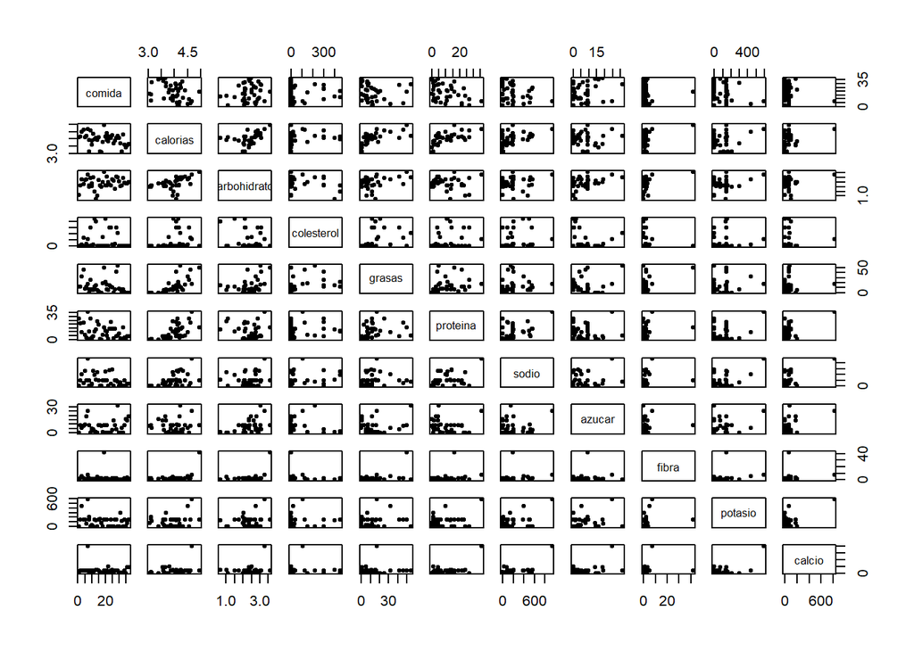

```r
pairs(datos2[c(1:11)],pch=20)
```

#### modelo simple (con la mejor gráfica)

Este primer modelo simple se hará comparando las calorías con los carbohidratos, esto se debe a que su gráfica tiene una apariencia más cercana a una recta.

```r
modelo_bueno<- lm(calorias~carbohidratos, data = datos2)

modelo_bueno
```

```
##
## Call:
## lm(formula = calorias ~ carbohidratos, data = datos2)
##
## Coefficients:
##   (Intercept)  carbohidratos
##        3.2271         0.3001
```

```r
summary(modelo_bueno)
```

```
##
## Call:
## lm(formula = calorias ~ carbohidratos, data = datos2)
##
## Residuals:
##      Min       1Q   Median       3Q      Max
## -0.77181 -0.38125  0.07495  0.40096  0.70921
##
## Coefficients:
##               Estimate Std. Error t value Pr(>|t|)
## (Intercept)    3.22713    0.08460   38.15  < 2e-16 ***
## carbohidratos  0.30008    0.03691    8.13 1.15e-14 ***
## ---
## Signif. codes:  0 '***' 0.001 '**' 0.01 '*' 0.05 '.' 0.1 ' ' 1
##
## Residual standard error: 0.4628 on 299 degrees of freedom
## Multiple R-squared:  0.181,  Adjusted R-squared:  0.1783
## F-statistic:  66.1 on 1 and 299 DF,  p-value: 1.15e-14
```

La R cuadrada es muy baja. Los valores p son menores a 0.05. El modelo matemático resultante es 3.22 + 0.3(carbohidratos). El error estándar de los coeficientes es 0.08 para las calorías y 0.03 para los carbohidratos. El error estándar del modelo es de 0.46

##### Diagnóstico del primer modelo

###### Significancia estadística de los coeficientes

Analizamos la tabla de resultados anterior. Recordemos que las hipótesis son:

H0:coeficiente es cero (debe quitarse del modelo)

Ha:coeficiente NO es cero (debe dejarse en el modelo)

Regla de decisión: si el valor-p>=0.05 (consideramos el 5% como nuestro riesgo de equivocarnos), entonces NO rechazamos H0 y en consecuencia el coeficiente en cuestión es estadísticamente igual a cero por lo que DEBE eliminarse del modelo

###### Gráficas de diagnóstico

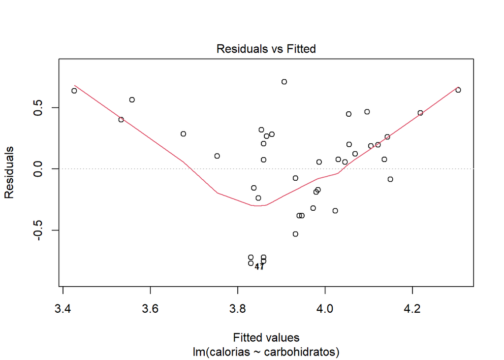

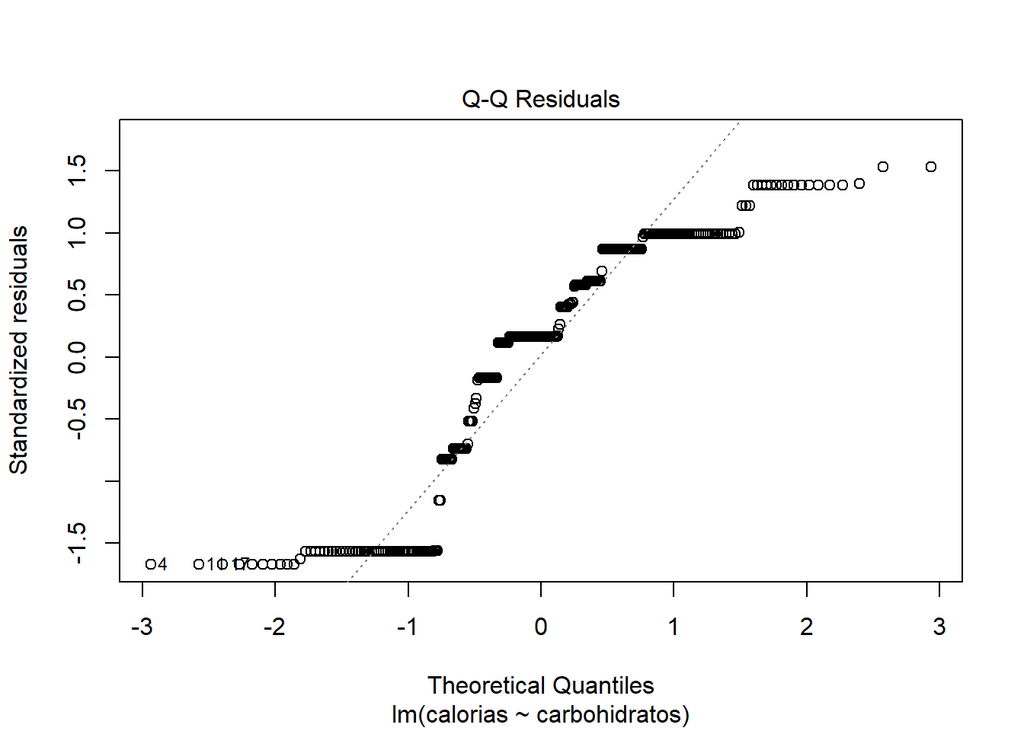

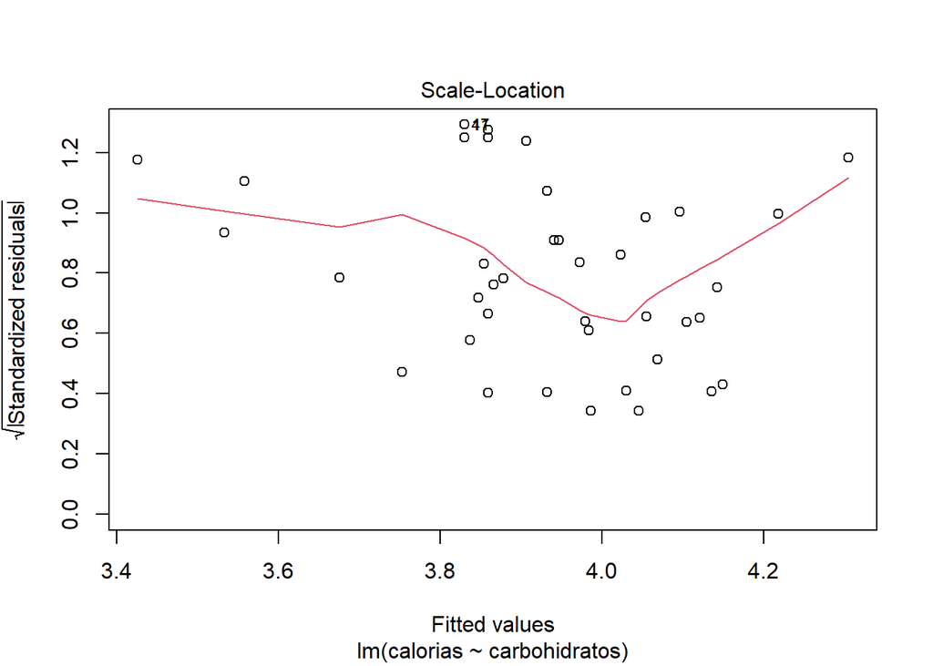

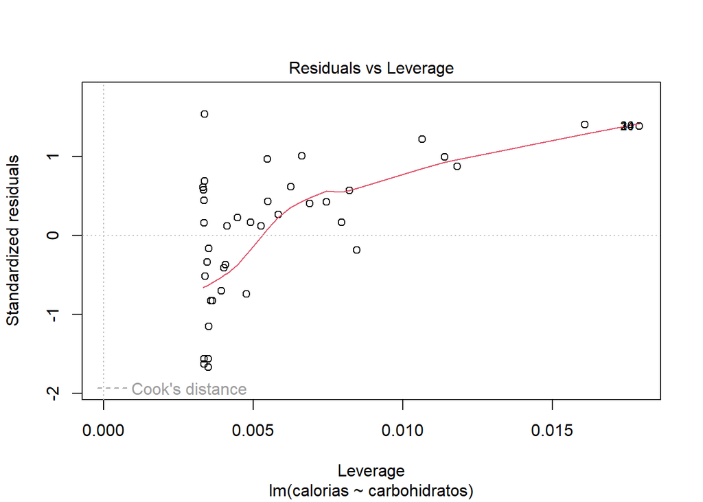

```r
plot(modelo_bueno)
```

La primera gráfica no tiene forma de línea horizontal. En la segunda gráfica los valores están muy alejados de la línea. La tercera gráfica tampoco es una línea horizontal y los valores se ven pegados hacia la izquierda. En el caso de la cuarta gráfica hay un dato que representa un riesgo. Probablemente este dato sean las palomitas para llevar del cine.

Esto significa que tendríamos que usar más variables para nuestro modelo.

##### Modelo simple (con la peor gráfica)

Este segundo modelo lo haremos con la proteína, la cual es una de las variables que tienen peores gráficas.

```r
modelo_malo<- lm(calorias~proteina, data = datos2)

modelo_malo
```

```
##
## Call:
## lm(formula = calorias ~ proteina, data = datos2)
##
## Coefficients:
## (Intercept)     proteina
##      3.4343       0.0348
```

```r
summary(modelo_malo)
```

```
##
## Call:
## lm(formula = calorias ~ proteina, data = datos2)
##
## Residuals:
##      Min       1Q   Median       3Q      Max
## -0.37570 -0.33255 -0.00512  0.17449  0.95658
##
## Coefficients:
##             Estimate Std. Error t value Pr(>|t|)
## (Intercept) 3.434334   0.023734  144.70   <2e-16 ***
## proteina    0.034798   0.001343   25.91   <2e-16 ***
## ---
## Signif. codes:  0 '***' 0.001 '**' 0.01 '*' 0.05 '.' 0.1 ' ' 1
##
## Residual standard error: 0.2839 on 299 degrees of freedom
## Multiple R-squared:  0.6919, Adjusted R-squared:  0.6909
## F-statistic: 671.5 on 1 and 299 DF,  p-value: < 2.2e-16
```

La R cuadrada no es muy grande, sin embargo es mayor que la del modelo anterior. Los valores p son menores a 0.05. El modelo matemático resultante es 3.43 + 0.03(proteína). El error estándar de los coeficientes es 0.02 para las calorías y 0.001 para la proteína. El error estándar del modelo es de 0.28.

##### Diagnóstico del modelo con la peor gráfica

###### Significancia estadística de los coeficientes

Analizamos la tabla de resultados anterior. Recordemos que las hipótesis son:

H0:coeficiente es cero (debe quitarse del modelo)

Ha:coeficiente NO es cero (debe dejarse en el modelo)

Regla de decisión: si el valor-p>=0.05 (consideramos el 5% como nuestro riesgo de equivocarnos), entonces NO rechazamos H0 y en consecuencia el coeficiente en cuestión es estadísticamente igual a cero por lo que DEBE eliminarse del modelo

###### Gráficas de diagnóstico

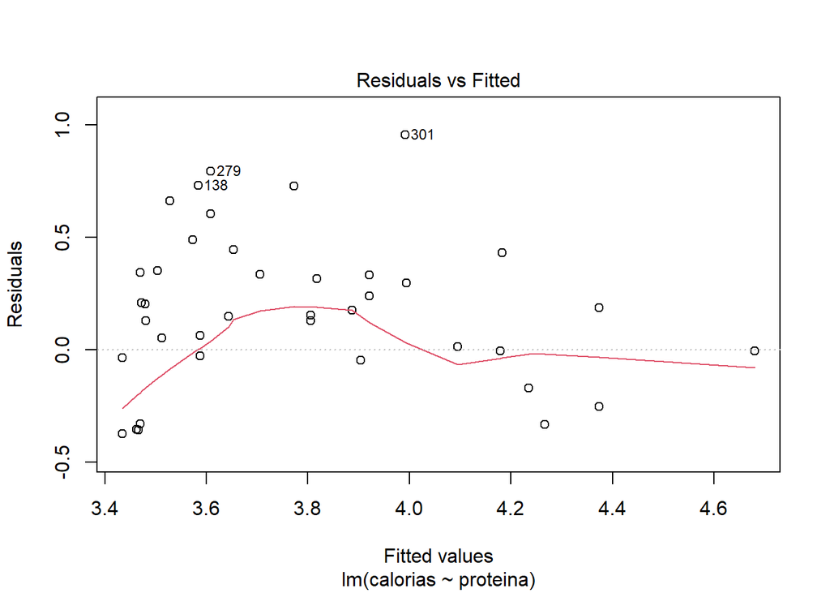

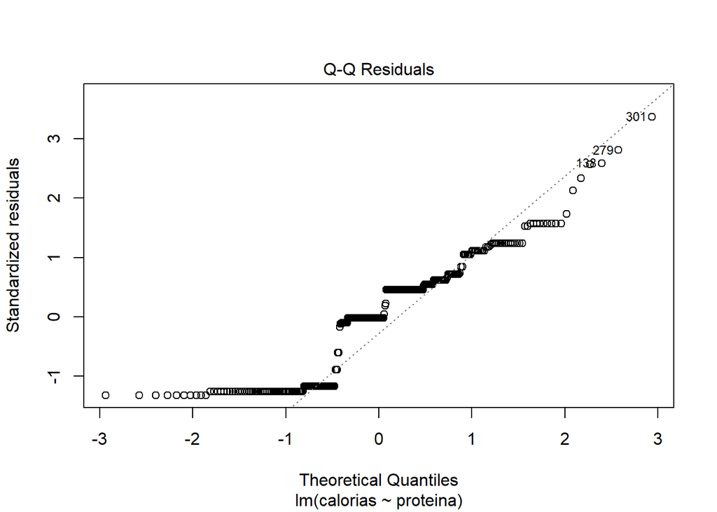

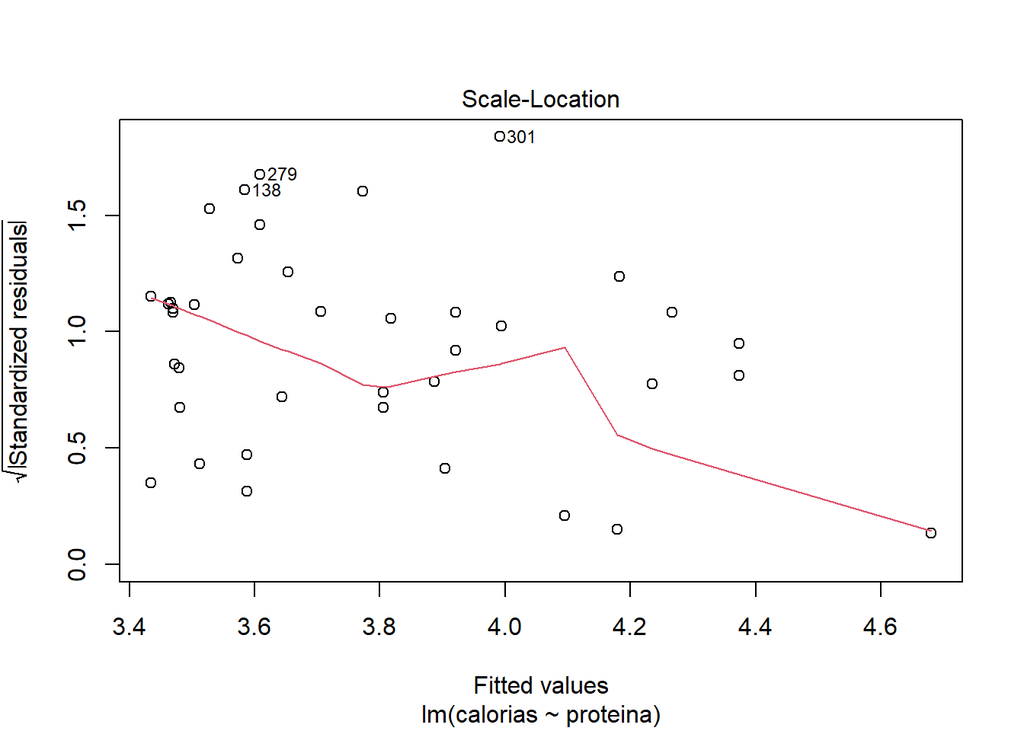

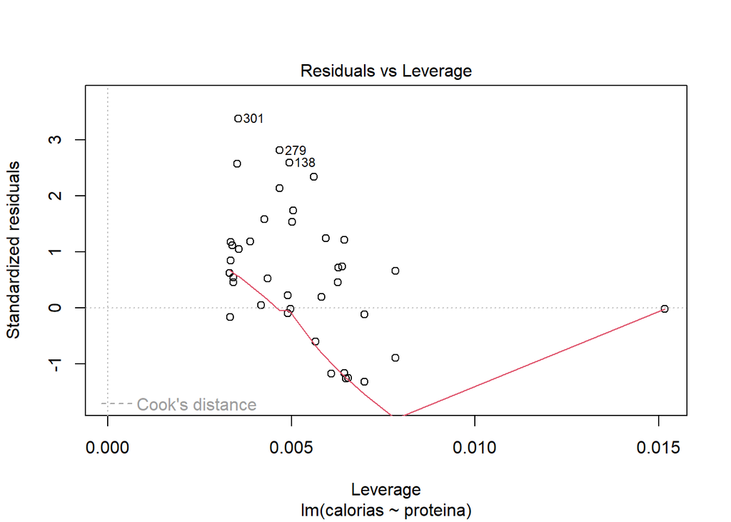

```r
plot(modelo_malo)
```

### Con los datos sin transformar

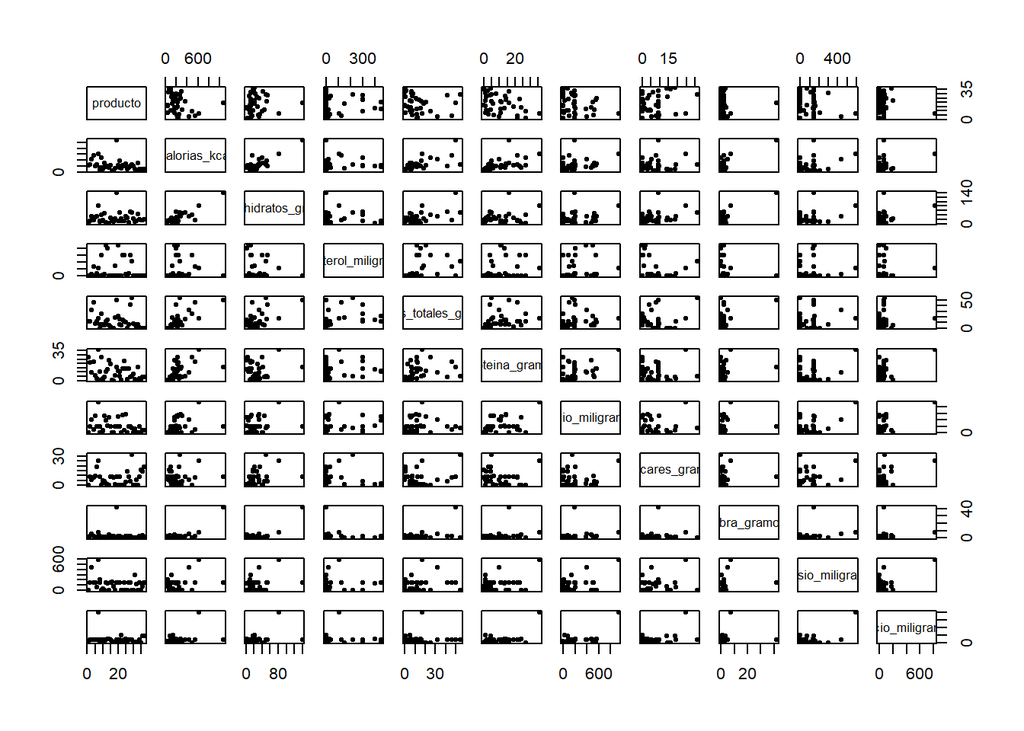

```r
datos$producto<- as.factor(datos$producto)
pairs(datos[c(3,4,5,6, 7, 10, 11, 12, 13, 14, 15)],pch=20)
```

#### modelo simple (con la mejor gráfica)

Este primer modelo simple se hará comparando las calorías con los carbohidratos, esto se debe a que su gráfica tiene una apariencia más cercana a una recta.

```r
modelo_1<- lm(calorias_kcal~carbohidratos_gramos, data = datos)

modelo_1
```

```
##
## Call:
## lm(formula = calorias_kcal ~ carbohidratos_gramos, data = datos)
##
## Coefficients:
##          (Intercept)  carbohidratos_gramos
##               58.281                 6.597
```

```r
summary(modelo_1)
```

```
##
## Call:
## lm(formula = calorias_kcal ~ carbohidratos_gramos, data = datos)
##
## Residuals:
##     Min      1Q  Median      3Q     Max
## -214.52  -84.55   22.44   62.56  393.76
##
## Coefficients:
##                      Estimate Std. Error t value Pr(>|t|)
## (Intercept)           58.2813     6.3271   9.211   <2e-16 ***
## carbohidratos_gramos   6.5970     0.1763  37.411   <2e-16 ***
## ---
## Signif. codes:  0 '***' 0.001 '**' 0.01 '*' 0.05 '.' 0.1 ' ' 1
##
## Residual standard error: 81.38 on 299 degrees of freedom
## Multiple R-squared:  0.824,  Adjusted R-squared:  0.8234
## F-statistic:  1400 on 1 and 299 DF,  p-value: < 2.2e-16
```

La R cuadrada no está tan mal, es mayor a los modelos de los datos transformados. Los valores p son menores a 0.05. El modelo matemático resultante es 58.28 + 6.59(carbohidratos). El error estándar de los coeficientes es 6.32 para las calorías y 0.17 para los carbohidratos El error estándar del modelo es de 81.38

##### Diagnóstico del primer modelo

###### Significancia estadística de los coeficientes

Analizamos la tabla de resultados anterior. Recordemos que las hipótesis son:

H0:coeficiente es cero (debe quitarse del modelo)

Ha:coeficiente NO es cero (debe dejarse en el modelo)

Regla de decisión: si el valor-p>=0.05 (consideramos el 5% como nuestro riesgo de equivocarnos), entonces NO rechazamos H0 y en consecuencia el coeficiente en cuestión es estadísticamente igual a cero por lo que DEBE eliminarse del modelo

###### Gráficas de diagnóstico

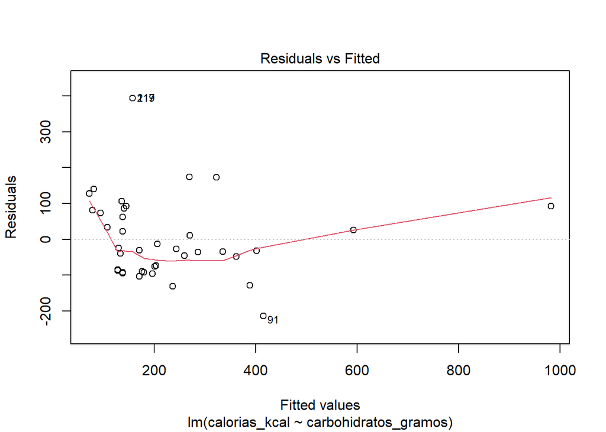

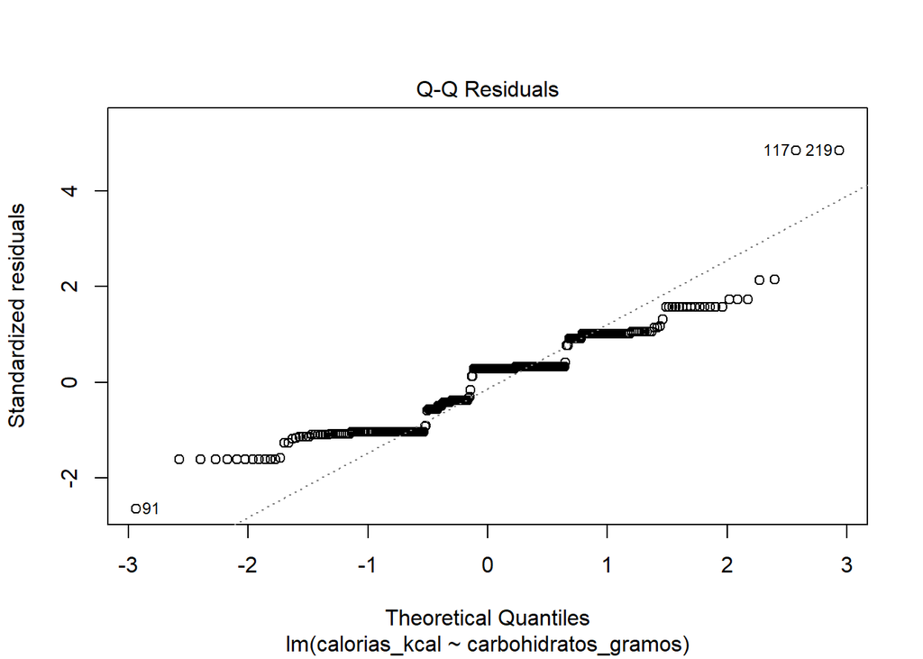

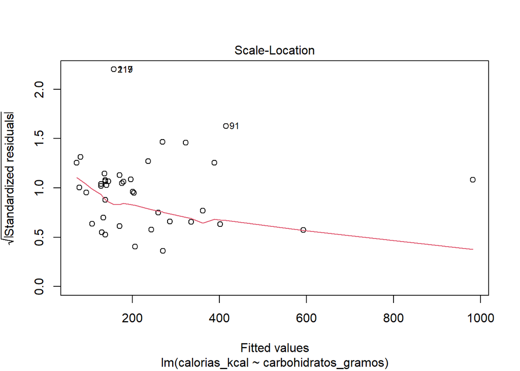

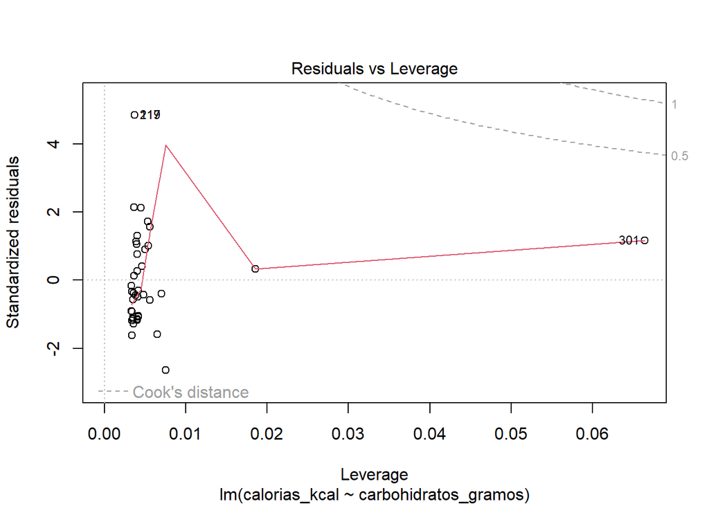

```r
plot(modelo_1)
```

En la primera gráfica la línea no es recta y los puntos parecen estar amontonados del lado izquierdo. Para la segunda gráfica, los valores no se muestran sobre la línea punteada. En la tercera gráfica, la línea tampoco es recta y los puntos están muy cargados a la izquierda. En la cuarta gráfica hay un dato riesgo, esto mismo pasó con el modelo de los datos transformados

#### Modelo simple (con la peor gráfica)

Este segundo modelo lo haremos con la proteína, la cual es una de las variables que tienen peores gráficas.

```r
modelo_2<- lm(calorias_kcal~proteina_gramos, data = datos)

modelo_2
```

```
##
## Call:
## lm(formula = calorias_kcal ~ proteina_gramos, data = datos)
##
## Coefficients:
##     (Intercept)  proteina_gramos
##            44.3             13.5
```

```r
summary(modelo_2)
```

```
##
## Call:
## lm(formula = calorias_kcal ~ proteina_gramos, data = datos)
##
## Residuals:
##     Min      1Q  Median      3Q     Max
## -207.35  -28.34  -13.45   68.70  813.69
##
## Coefficients:
##                 Estimate Std. Error t value Pr(>|t|)
## (Intercept)      44.3020     8.5201     5.2 3.71e-07 ***
## proteina_gramos  13.5004     0.4821    28.0  < 2e-16 ***
## ---
## Signif. codes:  0 '***' 0.001 '**' 0.01 '*' 0.05 '.' 0.1 ' ' 1
##
## Residual standard error: 101.9 on 299 degrees of freedom
## Multiple R-squared:  0.724,  Adjusted R-squared:  0.723
## F-statistic: 784.2 on 1 and 299 DF,  p-value: < 2.2e-16
```

La R cuadrada es más baja que la del modelo anterior. Mejor vamos a analizar las gráficas más adelante. Los valores p son menores a 0.05. El modelo matemático resultante es 44.30 + 13.5004(proteína). El error estándar de los coeficientes es 8.52 y 0.48. El error estándar del modelo es de 101.9

##### Diagnóstico del modelo con la peor gráfica

###### Significancia estadística de los coeficientes

Analizamos la tabla de resultados anterior. Recordemos que las hipótesis son:

H0:coeficiente es cero (debe quitarse del modelo)

Ha:coeficiente NO es cero (debe dejarse en el modelo)

Regla de decisión: si el valor-p>=0.05 (consideramos el 5% como nuestro riesgo de equivocarnos), entonces NO rechazamos H0 y en consecuencia el coeficiente en cuestión es estadísticamente igual a cero por lo que DEBE eliminarse del modelo

###### Gráficas de diagnóstico

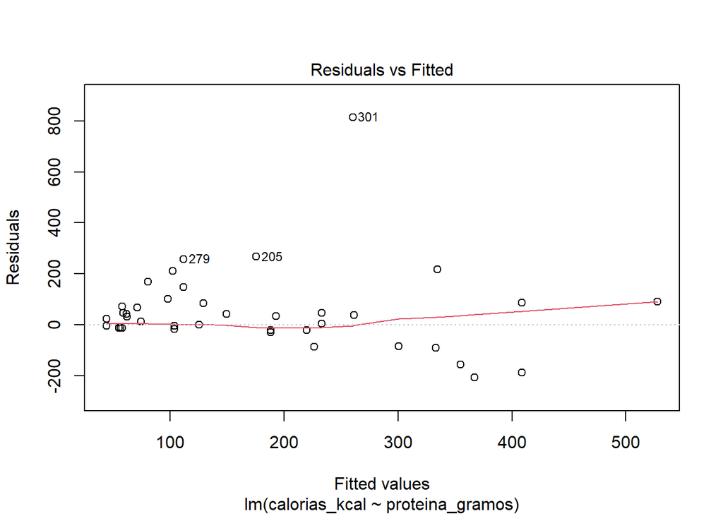

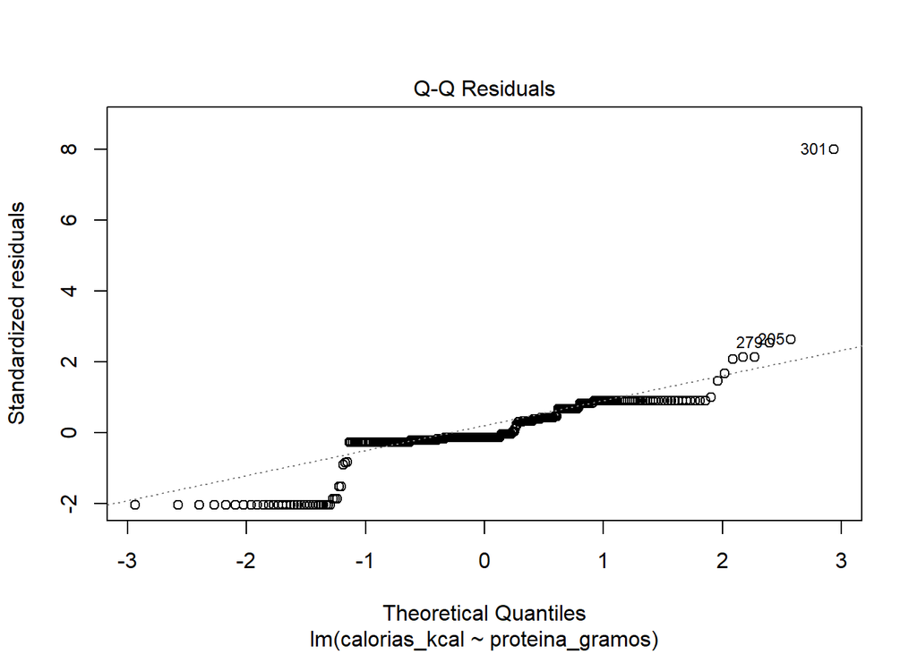

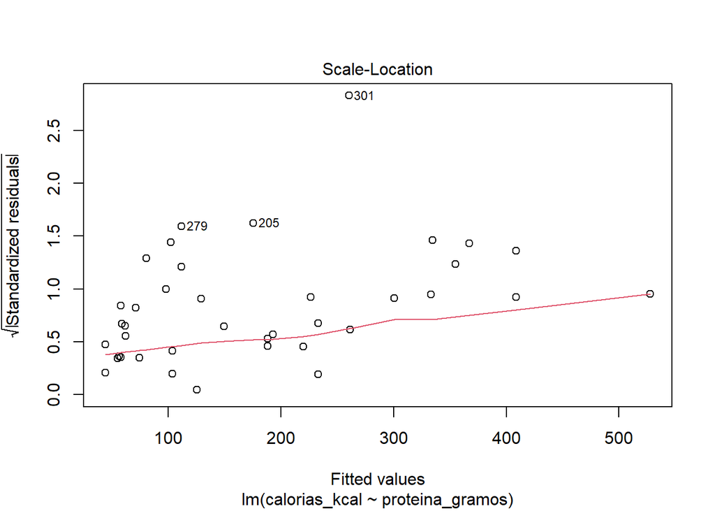

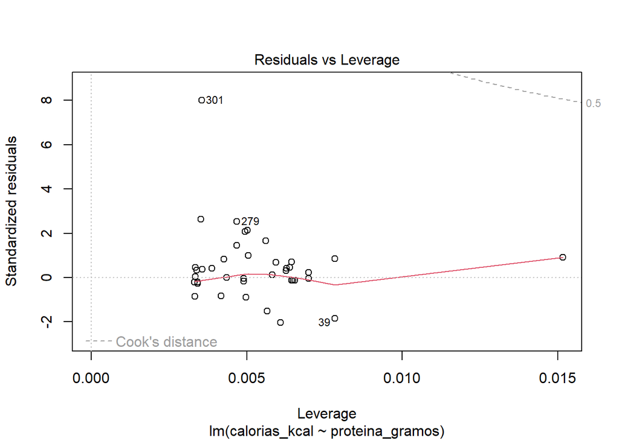

```r
plot(modelo_2)
```

La primera gráfica tiene una línea casi recta, sin embargo los puntos no están tan desordenados. En la segunda gráfica, hay varios valores que no tocan la línea punteada. En la tercera gráfica, la línea no está tan recta y los puntos tienen menos orden. En la cuarta gráfica, hay varios valores marcados como peligrosos.

## Decisión

Como podemos observar, el modelo queda mejor con los datos sin transformar. Así que vamos a crear una nueva tabla en la que solo vienen las variables que analizaremos de los datos sin transformar

```r
datos3 <- datos[, c(3,4,5,6, 7, 10, 11, 12, 13, 14, 15, 21)]
```

## Regresión lineal múltiple

### Relación entre las variables

Revisamos primero la matriz de gráficas de dispersión.

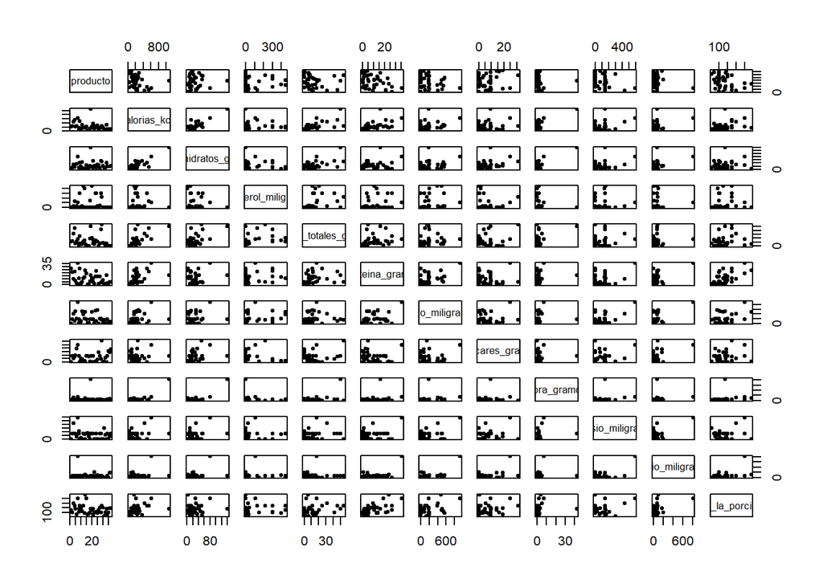

```r
datos3$producto<- as.factor(datos3$producto)
pairs(datos3[c(1:12)],pch=20)
```

O bien (sólo es válido para variables numéricas):

```r
# Seleccionamos solo las variables numéricas
library(dplyr)
numericas <- datos3 %>% select_if(is.numeric)

head(numericas)
```

| calorias_kcal | carbohidratos_gramos | colesterol_miligramos | grasas_totales_gramos | proteina_gramos | sodio_miligramos | azucares_gramos | fibra_gramos | potasio_miligramos | calcio_miligramos | tamano_de_la_porcion_gramos |
| --- | --- | --- | --- | --- | --- | --- | --- | --- | --- | --- |
| 167.00 | 5.33 | 450.0 | 11.41 | 10.66 | 390.00 | 1.76 | 1.00 | 143.0 | 70.00 | 250 |
| 43.00 | 10.50 | 0.0 | 0.20 | 0.90 | 12.00 | 9.10 | 1.80 | 208.8 | 4.98 | 112 |
| 159.88 | 3.00 | 0.0 | 5.80 | 23.92 | 480.00 | 0.33 | 3.92 | 0.0 | 105.00 | 480 |
| 40.00 | 10.50 | 0.0 | 0.00 | 0.00 | 1.00 | 8.00 | 2.50 | 70.0 | 0.08 | 70 |
| 67.00 | 17.00 | 0.0 | 0.20 | 0.00 | 2.00 | 16.00 | 0.90 | 0.0 | 0.00 | 100 |
| 619.00 | 81.00 | 106.5 | 17.10 | 35.80 | 930.25 | 24.90 | 7.30 | 589.6 | 815.70 | 400 |

```r
round(cor(numericas),digits=2)   # redondeamos a 2 decimales
```

```
##                             calorias_kcal carbohidratos_gramos
## calorias_kcal                        1.00                 0.91
## carbohidratos_gramos                 0.91                 1.00
## colesterol_miligramos                0.22                 0.01
## grasas_totales_gramos                0.73                 0.52
## proteina_gramos                      0.85                 0.66
## sodio_miligramos                     0.84                 0.72
## azucares_gramos                      0.64                 0.81
## fibra_gramos                         0.71                 0.70
## potasio_miligramos                   0.76                 0.80
## calcio_miligramos                    0.88                 0.88
## tamano_de_la_porcion_gramos          0.58                 0.44
##                             colesterol_miligramos grasas_totales_gramos
## calorias_kcal                                0.22                  0.73
## carbohidratos_gramos                         0.01                  0.52
## colesterol_miligramos                        1.00                  0.55
## grasas_totales_gramos                        0.55                  1.00
## proteina_gramos                              0.19                  0.56
## sodio_miligramos                             0.28                  0.55
## azucares_gramos                             -0.17                  0.23
## fibra_gramos                                -0.06                  0.44
## potasio_miligramos                           0.14                  0.39
## calcio_miligramos                            0.11                  0.46
## tamano_de_la_porcion_gramos                 -0.04                  0.31
##                             proteina_gramos sodio_miligramos azucares_gramos
## calorias_kcal                          0.85             0.84            0.64
## carbohidratos_gramos                   0.66             0.72            0.81
## colesterol_miligramos                  0.19             0.28           -0.17
## grasas_totales_gramos                  0.56             0.55            0.23
## proteina_gramos                        1.00             0.88            0.44
## sodio_miligramos                       0.88             1.00            0.54
## azucares_gramos                        0.44             0.54            1.00
## fibra_gramos                           0.58             0.59            0.49
## potasio_miligramos                     0.62             0.72            0.82
## calcio_miligramos                      0.83             0.87            0.80
## tamano_de_la_porcion_gramos            0.83             0.76            0.29
##                             fibra_gramos potasio_miligramos calcio_miligramos
## calorias_kcal                       0.71               0.76              0.88
## carbohidratos_gramos                0.70               0.80              0.88
## colesterol_miligramos              -0.06               0.14              0.11
## grasas_totales_gramos               0.44               0.39              0.46
## proteina_gramos                     0.58               0.62              0.83
## sodio_miligramos                    0.59               0.72              0.87
## azucares_gramos                     0.49               0.82              0.80
## fibra_gramos                        1.00               0.56              0.62
## potasio_miligramos                  0.56               1.00              0.89
## calcio_miligramos                   0.62               0.89              1.00
## tamano_de_la_porcion_gramos         0.53               0.37              0.63
##                             tamano_de_la_porcion_gramos
## calorias_kcal                                      0.58
## carbohidratos_gramos                               0.44
## colesterol_miligramos                             -0.04
## grasas_totales_gramos                              0.31
## proteina_gramos                                    0.83
## sodio_miligramos                                   0.76
## azucares_gramos                                    0.29
## fibra_gramos                                       0.53
## potasio_miligramos                                 0.37
## calcio_miligramos                                  0.63
## tamano_de_la_porcion_gramos                        1.00
```

### Un primer modelo general: todas las variables

```r
modelo<- lm(calorias_kcal~carbohidratos_gramos+colesterol_miligramos+grasas_totales_gramos+proteina_gramos+sodio_miligramos+azucares_gramos+fibra_gramos+potasio_miligramos+calcio_miligramos+tamano_de_la_porcion_gramos+producto, data = datos3)


summary(modelo)
```

```
##
## Call:
## lm(formula = calorias_kcal ~ carbohidratos_gramos + colesterol_miligramos +
##     grasas_totales_gramos + proteina_gramos + sodio_miligramos +
##     azucares_gramos + fibra_gramos + potasio_miligramos + calcio_miligramos +
##     tamano_de_la_porcion_gramos + producto, data = datos3)
##
## Residuals:
##        Min         1Q     Median         3Q        Max
## -7.651e-12 -5.700e-15  0.000e+00  2.830e-14  8.968e-12
##
## Coefficients: (7 not defined because of singularities)
##                                    Estimate Std. Error    t value Pr(>|t|)
## (Intercept)                      -4.068e+01  3.517e-12 -1.157e+13   <2e-16 ***
## carbohidratos_gramos              4.246e+00  2.503e-14  1.696e+14   <2e-16 ***
## colesterol_miligramos            -2.932e+00  2.484e-13 -1.180e+13   <2e-16 ***
## grasas_totales_gramos             9.383e+00  1.620e-13  5.793e+13   <2e-16 ***
## proteina_gramos                   3.985e+00  1.117e-13  3.567e+13   <2e-16 ***
## sodio_miligramos                  8.416e-02  3.774e-15  2.230e+13   <2e-16 ***
## azucares_gramos                   6.525e-01  1.349e-13  4.838e+12   <2e-16 ***
## fibra_gramos                      3.503e+00  5.958e-13  5.880e+12   <2e-16 ***
## potasio_miligramos                6.159e-02  9.692e-15  6.355e+12   <2e-16 ***
## calcio_miligramos                -2.023e-01  1.835e-14 -1.102e+13   <2e-16 ***
## tamano_de_la_porcion_gramos       1.986e-01  1.357e-14  1.464e+13   <2e-16 ***
## productocamarones_empanizados    -9.947e+00  2.214e-12 -4.494e+12   <2e-16 ***
## productochilaquiles              -5.111e+01  5.787e-12 -8.832e+12   <2e-16 ***
## productochile_en_nogada           3.209e+02  2.583e-11  1.243e+13   <2e-16 ***
## productocuernito                 -5.286e+01  2.363e-12 -2.237e+13   <2e-16 ***
## productodona                      8.542e+01  7.647e-12  1.117e+13   <2e-16 ***
## productoensalada                  2.540e+02  2.528e-11  1.005e+13   <2e-16 ***
## productofruta                    -1.372e+01  1.836e-12 -7.470e+12   <2e-16 ***
## productohamburguesa_con_papas     8.535e+02  7.187e-11  1.188e+13   <2e-16 ***
## productohot_cakes                 4.068e+01  3.838e-12  1.060e+13   <2e-16 ***
## productohot_cakes_ihop            8.783e+01  5.973e-12  1.470e+13   <2e-16 ***
## productohuevo_con_chorizo         1.273e+03  1.099e-10  1.158e+13   <2e-16 ***
## productohuevo_con_jamon           1.185e+03  9.993e-11  1.186e+13   <2e-16 ***
## productolicuado_de_proteina      -9.036e+01  4.518e-12 -2.000e+13   <2e-16 ***
## productolicuado_frutos_rojos     -6.627e+01  4.651e-12 -1.425e+13   <2e-16 ***
## productomandarina                 2.291e+00  1.095e-12  2.092e+12   <2e-16 ***
## productomanzana                   3.837e+00  8.421e-13  4.556e+12   <2e-16 ***
```

[output cut: 11 more lines]

```
## productorebanada_red_velvet       1.265e+02  4.668e-11  2.709e+12   <2e-16 ***
## productorollitos_pollo_con_queso -5.487e+00  1.849e-12 -2.968e+12   <2e-16 ***
## productoruffles                          NA         NA         NA       NA
## productosandia                           NA         NA         NA       NA
## productosandwich                         NA         NA         NA       NA
## productosope                             NA         NA         NA       NA
## productouvas                             NA         NA         NA       NA
## productoyogurt_con_manzana               NA         NA         NA       NA
## productoyogurt_con_uvas                  NA         NA         NA       NA
## ---
## Signif. codes:  0 '***' 0.001 '**' 0.01 '*' 0.05 '.' 0.1 ' ' 1
##
## Residual standard error: 9.707e-13 on 261 degrees of freedom
## Multiple R-squared:      1,  Adjusted R-squared:      1
## F-statistic: 3.061e+29 on 39 and 261 DF,  p-value: < 2.2e-16
```

La r cuadrada da 1, lo cual es sospechoso. Lo más probable es que esto esté sucediendo debido a los productos. El valor p es menor a 0.05. Todos los coeficientes de las variables también son menores a 0.05. Es por eso que nos vamos a quedar con todas las variables.

#### Expresión matemática

La expresión matemática quedaría como (-4.068e+01) + 4.246e+00(carbohidratos) - 2.932e+00(colesterol) + 9.383e+00(grasas totales) + 3.985e+00(proteína) + 8.416e-02(sodio) + 6.525e-01(azúcares) + 3.503e+00(fibra) + 6.159e-02(potasio) - 2.023e-012(calcio) + 1.986e-01(tamaño de la porción) - 9.947e+00(camarones empanizados) - 5.111e+01(chilaquiles) + 3.209e+02(chiles en nogada) - 5.286e+01(cuernito) + 8.542e+01(dona) + 2.540e+02(ensalada) - 1.372e+01(fruta) + 8.535e+02(hamburguesa con papas) + 4.068e+01(hot cakes) + 8.783e+01(hot cakes ihop) + 1.273e+03(huevo con chorizo) + 1.185e+03(huevo con jamón) - 9.036e+01(licuado de proteína) - 6.627e+01(licuado frutos rojos) + 2.291e+00(mandarina) + 3.837e+00(manzana) + 2.799e+02(media gordita) - 2.115e+02(palomitas doritos) + 1.205e+03(pan tostado con huevo) - 1.372e+01(panqué de limón) + 4.179e+01(papas a la francesa) + 8.448e+02(pechuga cordon blue) + 8.410e+02(picaña) + 4.735e+01(pizza) - 1.708e+01(plátano) + 7.961e+01(pollo enchilado) + 4.407e+02(panqué de arándano) + 1.265e+02(rebanada red velvet) - 5.487e+00(rollitos de pollo con queso)

También se muestra el error de cada coeficiente y del modelo completo (9.707e-13) El error de cada coeficiente es 3.517e-12(intercept), 2.503e-14(carbohidratos), 2.484e-13(colesterol), 1.620e-13(grasas totales), 1.117e-13(proteína), 3.774e-15(sodio), 1.349e-13(azúcares), 5.958e-13(fibra), 9.692e-15(potasio), 1.835e-14(calcio), 1.357e-14(tamaño de la porción), 2.214e-12(camarones empanizados), 5.787e-12(chilaquiles), 2.583e-11(chile en nogada), 2.363e-12(cuernito), 7.647e-12(dona), 2.528e-11(ensalada), 1.836e-12(fruta), 7.187e-11(hamburguesa con papas), 3.838e-12(hot cakes), 5.973e-12(hot cakes ihop), 1.099e-10(huevo con chorizo), 9.993e-11(huevo con jamón), 4.518e-12(licuado de proteína), 4.651e-12(licuado de frutos rojos), 1.095e-12(mandarina), 8.421e-13(manzana), 3.674e-11(media gordita), 3.022e-11(palomitas doritos), 1.087e-10(pan tostado con huevo), 1.842e-12(panqué de limón), 4.986e-12(papas a la francesa), 7.461e-11(pechuga cordon blue), 7.486e-11(picaña), 7.366e-12(pizza), 7.940e-13(plátano), 7.867e-12(pollo enchilado), 7.050e-11(rebanada de panqué de arándano), 4.668e-11(rebanada red velvet), 1.849e-12(rollitos de pollo con queso)

Vamos a analizar las gráficas de diagnóstico

#### Gráficas de diagnóstico

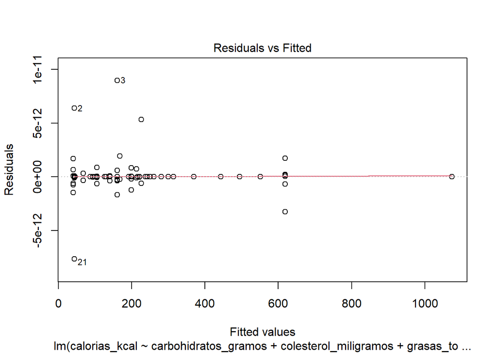

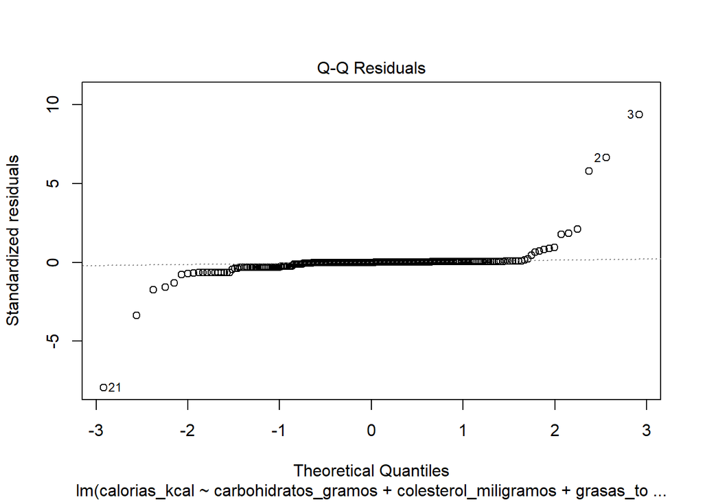

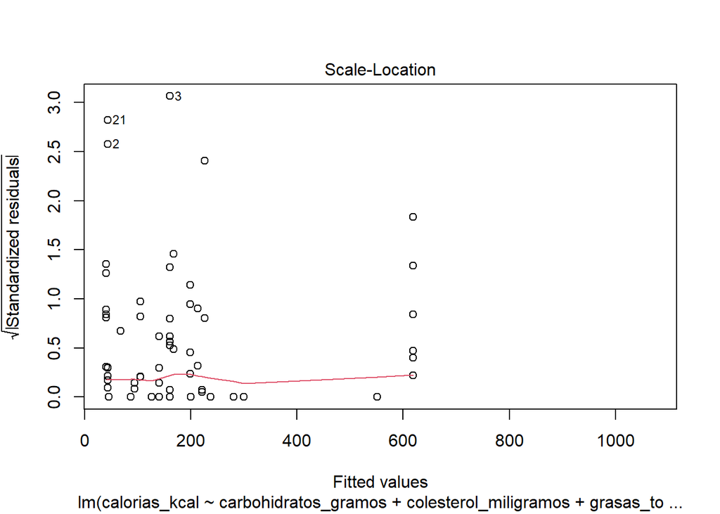

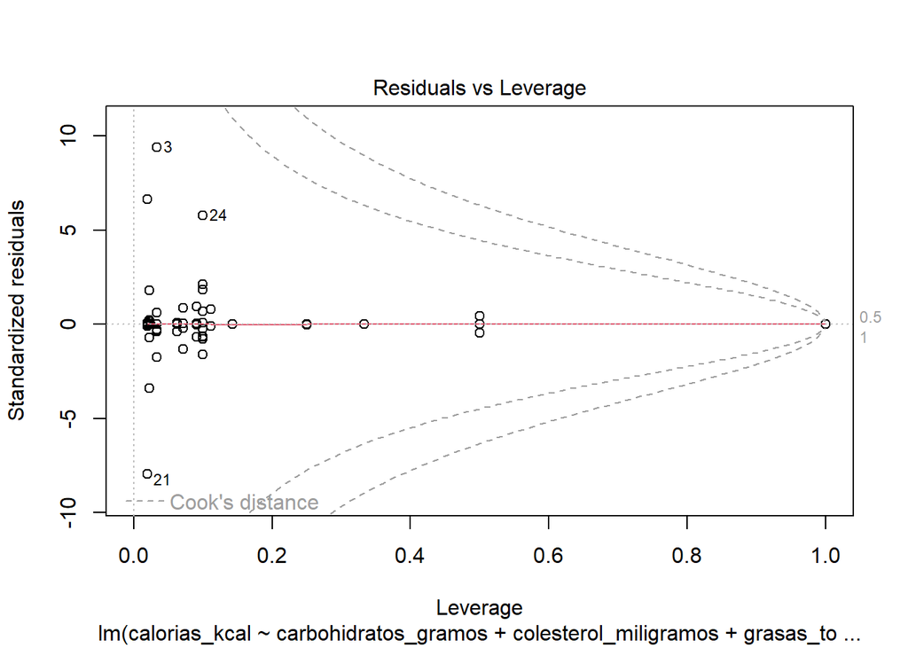

```r
plot(modelo)
```

En la primera gráfica la línea está recta, sin embargo los puntos no se ven tan distribuidos. En la segunda gráfica hay varios valores que no se encuentran sobre la línea, sin emgbargo ya hay más puntos que se encuentran sobre la línea que en modelos pasados. En la tercera gráfica, se ve una línea casi recta y los puntos no están tan distribuidos. En la tercera gráfica vemos que hay algunos valores que presentan un peligro.